# cs02_v5_backup

## Case Study 2: Diabetes Dataset

### Prediction of Hospital Readmittance Class and Interpretation of Important Predictors

### May 27, 2025

Your case study is to build classifiers using logistic regression to predict ALL 3 CATEGORIES of hospital re-admittance. There is missing data that must be imputed.

Once again, discuss the top 5 variable importance of your best model as part of your submission.

### Import Libraries and Set Global Seed

```python
import numpy as np
import pandas as pd
import matplotlib.pyplot as plt
import seaborn as sns
from sklearn.preprocessing import RobustScaler
from sklearn.model_selection import StratifiedKFold, GridSearchCV, cross_validate, cross_val_predict
from sklearn.linear_model import LogisticRegression
from sklearn.metrics import classification_report, confusion_matrix, precision_recall_curve, ConfusionMatrixDisplay, f1_score, accuracy_score, precision_score, recall_score, roc_auc_score
from sklearn.preprocessing import LabelEncoder, label_binarize
from scipy.stats import loguniform

%matplotlib inline

SEED = 13
```

### Import and View Data

```python
raw_data = pd.read_csv('data/diabetic_data.csv')
raw_data.head()
```

|  | encounter_id | patient_nbr | race | gender | age | weight | admission_type_id | discharge_disposition_id | admission_source_id | time_in_hospital | ... | citoglipton | insulin | glyburide-metformin | glipizide-metformin | glimepiride-pioglitazone | metformin-rosiglitazone | metformin-pioglitazone | change | diabetesMed | readmitted |
| --- | --- | --- | --- | --- | --- | --- | --- | --- | --- | --- | --- | --- | --- | --- | --- | --- | --- | --- | --- | --- | --- |
| 0 | 2278392 | 8222157 | Caucasian | Female | [0-10) | ? | 6 | 25 | 1 | 1 | ... | No | No | No | No | No | No | No | No | No | NO |
| 1 | 149190 | 55629189 | Caucasian | Female | [10-20) | ? | 1 | 1 | 7 | 3 | ... | No | Up | No | No | No | No | No | Ch | Yes | >30 |
| 2 | 64410 | 86047875 | AfricanAmerican | Female | [20-30) | ? | 1 | 1 | 7 | 2 | ... | No | No | No | No | No | No | No | No | Yes | NO |
| 3 | 500364 | 82442376 | Caucasian | Male | [30-40) | ? | 1 | 1 | 7 | 2 | ... | No | Up | No | No | No | No | No | Ch | Yes | NO |
| 4 | 16680 | 42519267 | Caucasian | Male | [40-50) | ? | 1 | 1 | 7 | 1 | ... | No | Steady | No | No | No | No | No | Ch | Yes | NO |

5 rows × 50 columns

```python
raw_data.shape
```

```
(101766, 50)
```

There are 101,766 observations of 50 features.

```python
raw_data.info()
```

```
<class 'pandas.core.frame.DataFrame'>
RangeIndex: 101766 entries, 0 to 101765
Data columns (total 50 columns):
 #   Column                    Non-Null Count   Dtype
---  ------                    --------------   -----
 0   encounter_id              101766 non-null  int64
 1   patient_nbr               101766 non-null  int64
 2   race                      101766 non-null  object
 3   gender                    101766 non-null  object
 4   age                       101766 non-null  object
 5   weight                    101766 non-null  object
 6   admission_type_id         101766 non-null  int64
 7   discharge_disposition_id  101766 non-null  int64
 8   admission_source_id       101766 non-null  int64
 9   time_in_hospital          101766 non-null  int64
```

[output cut: 42 more lines]

The target variable 'readmitted' is a categorical variable. There are 36 other categorical variables and 13 numerical in the raw dataset.

```python
# How much overlap is there between diagnosis codes across diagnoses columns?

# Get number of unique values in each column
print("Number of unique values in each column:")
print("diag_1:", raw_data['diag_1'].nunique())
print("diag_2:", raw_data['diag_2'].nunique())
print("diag_3:", raw_data['diag_3'].nunique())

# Check for overlap between columns
print("\nOverlap analysis:")
# Values in diag_1 that are also in diag_2
overlap_1_2 = set(raw_data['diag_1'].unique()) & set(raw_data['diag_2'].unique())
print("Number of values common to diag_1 and diag_2:", len(overlap_1_2))

# Values in diag_1 that are also in diag_3
overlap_1_3 = set(raw_data['diag_1'].unique()) & set(raw_data['diag_3'].unique())
print("Number of values common to diag_1 and diag_3:", len(overlap_1_3))

# Values in diag_2 that are also in diag_3
overlap_2_3 = set(raw_data['diag_2'].unique()) & set(raw_data['diag_3'].unique())
print("Number of values common to diag_2 and diag_3:", len(overlap_2_3))

# Values common to all three columns
overlap_all = set(raw_data['diag_1'].unique()) & set(raw_data['diag_2'].unique()) & set(raw_data['diag_3'].unique())
print("Number of values common to all three columns:", len(overlap_all))

# Count patients with at least 2 identical codes
duplicates = ((raw_data['diag_1'] == raw_data['diag_2']) |
              (raw_data['diag_1'] == raw_data['diag_3']) |
              (raw_data['diag_2'] == raw_data['diag_3']))

# Count total duplicates
total_duplicates = duplicates.sum()
print(f"\nNumber of patients with at least 2 identical diagnosis codes: {total_duplicates}")
print(f"Percentage of patients with duplicates: {(total_duplicates/len(raw_data))*100:.2f}%")

# Show sample of patients with duplicates
print("\nSample of patients with duplicate codes:")
print(raw_data[duplicates][['diag_1', 'diag_2', 'diag_3']].head())
```

```
Number of unique values in each column:
diag_1: 717
diag_2: 749
diag_3: 790

Overlap analysis:
Number of values common to diag_1 and diag_2: 604
Number of values common to diag_1 and diag_3: 618
Number of values common to diag_2 and diag_3: 690
Number of values common to all three columns: 572

Number of patients with at least 2 identical diagnosis codes: 5771
Percentage of patients with duplicates: 5.67%

Sample of patients with duplicate codes:
    diag_1 diag_2 diag_3
0   250.83      ?      ?
54     618    997    618
66  250.11      ?      ?
68     414    424    424
81     198    197    197
```

Each diagnosis feature has 717-790 unique codes, but there is significant overlap in codes between diagnosis 1, 2 and 3 across the dataset. Also, about 6% of patients have duplicate codes.

### Find Missing Data

```python
missing_data = raw_data.describe(include='all')
missing_data
```

|  | encounter_id | patient_nbr | race | gender | age | weight | admission_type_id | discharge_disposition_id | admission_source_id | time_in_hospital | ... | citoglipton | insulin | glyburide-metformin | glipizide-metformin | glimepiride-pioglitazone | metformin-rosiglitazone | metformin-pioglitazone | change | diabetesMed | readmitted |
| --- | --- | --- | --- | --- | --- | --- | --- | --- | --- | --- | --- | --- | --- | --- | --- | --- | --- | --- | --- | --- | --- |
| count | 1.017660e+05 | 1.017660e+05 | 101766 | 101766 | 101766 | 101766 | 101766.000000 | 101766.000000 | 101766.000000 | 101766.000000 | ... | 101766 | 101766 | 101766 | 101766 | 101766 | 101766 | 101766 | 101766 | 101766 | 101766 |
| unique | NaN | NaN | 6 | 3 | 10 | 10 | NaN | NaN | NaN | NaN | ... | 1 | 4 | 4 | 2 | 2 | 2 | 2 | 2 | 2 | 3 |
| top | NaN | NaN | Caucasian | Female | [70-80) | ? | NaN | NaN | NaN | NaN | ... | No | No | No | No | No | No | No | No | Yes | NO |
| freq | NaN | NaN | 76099 | 54708 | 26068 | 98569 | NaN | NaN | NaN | NaN | ... | 101766 | 47383 | 101060 | 101753 | 101765 | 101764 | 101765 | 54755 | 78363 | 54864 |
| mean | 1.652016e+08 | 5.433040e+07 | NaN | NaN | NaN | NaN | 2.024006 | 3.715642 | 5.754437 | 4.395987 | ... | NaN | NaN | NaN | NaN | NaN | NaN | NaN | NaN | NaN | NaN |
| std | 1.026403e+08 | 3.869636e+07 | NaN | NaN | NaN | NaN | 1.445403 | 5.280166 | 4.064081 | 2.985108 | ... | NaN | NaN | NaN | NaN | NaN | NaN | NaN | NaN | NaN | NaN |
| min | 1.252200e+04 | 1.350000e+02 | NaN | NaN | NaN | NaN | 1.000000 | 1.000000 | 1.000000 | 1.000000 | ... | NaN | NaN | NaN | NaN | NaN | NaN | NaN | NaN | NaN | NaN |
| 25% | 8.496119e+07 | 2.341322e+07 | NaN | NaN | NaN | NaN | 1.000000 | 1.000000 | 1.000000 | 2.000000 | ... | NaN | NaN | NaN | NaN | NaN | NaN | NaN | NaN | NaN | NaN |
| 50% | 1.523890e+08 | 4.550514e+07 | NaN | NaN | NaN | NaN | 1.000000 | 1.000000 | 7.000000 | 4.000000 | ... | NaN | NaN | NaN | NaN | NaN | NaN | NaN | NaN | NaN | NaN |
| 75% | 2.302709e+08 | 8.754595e+07 | NaN | NaN | NaN | NaN | 3.000000 | 4.000000 | 7.000000 | 6.000000 | ... | NaN | NaN | NaN | NaN | NaN | NaN | NaN | NaN | NaN | NaN |
| max | 4.438672e+08 | 1.895026e+08 | NaN | NaN | NaN | NaN | 8.000000 | 28.000000 | 25.000000 | 14.000000 | ... | NaN | NaN | NaN | NaN | NaN | NaN | NaN | NaN | NaN | NaN |

11 rows × 50 columns

```python
for i in missing_data.columns:
    if missing_data.loc['count', i] != raw_data.shape[0]: # by row name
        num_missing = raw_data.shape[0] - missing_data.loc['count', i]
        percent_missing = (num_missing / raw_data.shape[0]) * 100
        print(f' {i} has {num_missing} missing values, which is {percent_missing:.2f}% of the feature values.')
```

```
 max_glu_serum has 96420 missing values, which is 94.75% of the feature values.
 A1Cresult has 84748 missing values, which is 83.28% of the feature values.
```

#### Summarize NaNs

```python
# Find the NaNs in the dataset
nan_sums = raw_data.isna().sum()
nan_sums_nonzero = nan_sums[nan_sums != 0]
nan_sums_nonzero

# Calculate percentages
nan_percentages = (nan_sums_nonzero / len(raw_data)) * 100

# Create a DataFrame of NaN counts and percentages
nan_summary = pd.DataFrame({
    'NaN Count': nan_sums_nonzero,
    'NaN Percentage': nan_percentages
}).sort_values(by='NaN Count', ascending=False)
nan_sums_nonzero

nan_summary
```

|  | NaN Count | NaN Percentage |
| --- | --- | --- |
| max_glu_serum | 96420 | 94.746772 |
| A1Cresult | 84748 | 83.277322 |

These are listed as 'None' in the csv file but pandas by default converts None to NaN. I reconvert them to an Untested category.

#### Summarize Other Forms of Missing Values (`?`s or empty strings)

```python
# Find `?` values and decide how to deal with them
questionmark_sums = (raw_data == '?').sum()
questionmark_sums_nonzero = questionmark_sums[questionmark_sums != 0]
questionmark_sums_nonzero

# Calculate percentages
questionmark_percentages = (questionmark_sums_nonzero / len(raw_data)) * 100

# Create a DataFrame of NaN counts and percentages
questionmark_summary = pd.DataFrame({
    '? Count': questionmark_sums_nonzero,
    '? Percentage': questionmark_percentages
}).sort_values(by='? Count', ascending=False)
questionmark_sums_nonzero

questionmark_summary
```

|  | ? Count | ? Percentage |
| --- | --- | --- |
| weight | 98569 | 96.858479 |
| medical_specialty | 49949 | 49.082208 |
| payer_code | 40256 | 39.557416 |
| race | 2273 | 2.233555 |
| diag_3 | 1423 | 1.398306 |
| diag_2 | 358 | 0.351787 |
| diag_1 | 21 | 0.020636 |

```python
# Are there any empty strings
# Find `?` values and decide how to deal with them
emptystrings_sums = (raw_data == '').sum()
emptystrings_sums_nonzero = emptystrings_sums[emptystrings_sums != 0]
emptystrings_sums_nonzero
```

```
Series([], dtype: int64)
```

```python
# Find the unknown codes for each integer-coded variable and decide how to deal with them
unknown_codes = {
    'admission_type_id': [5, 6, 8],  # Not Available, NULL, Not Mapped
    'discharge_disposition_id': [18, 25],  # NULL, Not Mapped
    'admission_source_id': [9, 17, 20]  # Not Available, NULL, Not Mapped
}

# Create a summary DataFrame
unknown_summary = []

for col, codes in unknown_codes.items():
    for code in codes:
        count = (raw_data[col] == code).sum()
        percent = 100 * count / len(raw_data)
        unknown_summary.append({
            'Variable': col,
            'Unknown Code': code,
            'Count': count,
            'Percentage': percent
        })

unknown_summary_df = pd.DataFrame(unknown_summary)
print(unknown_summary_df)
```

```
                   Variable  Unknown Code  Count  Percentage
0         admission_type_id             5   4785    4.701963
1         admission_type_id             6   5291    5.199182
2         admission_type_id             8    320    0.314447
3  discharge_disposition_id            18   3691    3.626948
4  discharge_disposition_id            25    989    0.971837
5       admission_source_id             9    125    0.122831
6       admission_source_id            17   6781    6.663326
7       admission_source_id            20    161    0.158206
```

In `admission_type_id`, 5.2% of values are NULL, and another ~5% are Not Available or Not Mapped. In `admission_source_id`, 6.7% are NULL, 0.1% are Not Available and 0.2% are Not Mapped. In `discharge_disposition_id`, 3.6% are NULL and 1.0% are Not Mapped.

#### Examine Missings: `Weight`

```python
# How many missing values are in each weight class?

# Define the order for weight classes
weight_order = [
    "[0-25)", "[25-50)", "[50-75)", "[75-100)", "[100-125)",
    "[125-150)", "[150-175)", "[175-200)", ">200", '?'
]

weight_counts = raw_data['weight'].value_counts(dropna=False)

# Reindex the counts based on the custom order
sorted_weight_counts = weight_counts.reindex(weight_order)
sorted_weight_counts
```

```
weight
[0-25)          48
[25-50)         97
[50-75)        897
[75-100)      1336
[100-125)      625
[125-150)      145
[150-175)       35
[175-200)       11
>200             3
?            98569
Name: count, dtype: int64
```

Nearly 97% of weights are missing. Imputatation is impractical. I will drop this column.

#### Examine Missings: `max_glu_serum` and `A1Cresult`

~95% of `max_glu_serum` and ~83% of `A1Cresult` values are missing.

```python
raw_data['max_glu_serum'].value_counts(dropna=False)
```

```
max_glu_serum
NaN     96420
Norm     2597
>200     1485
>300     1264
Name: count, dtype: int64
```

```python
raw_data['A1Cresult'].value_counts(dropna=False)
```

```
A1Cresult
NaN     84748
>8       8216
Norm     4990
>7       3812
Name: count, dtype: int64
```

The data description specifies that the categorical levels for these test result variables (glucose serum and hemoglobin A1c) have four categorical levels. glucose serum levels: >200, >300, normal, none hemoglobin A1c levels: >8, >7, normal, none There is a 'none' category in the raw data file. The default pandas behavior is to import 'none' values as NaN. It is plausible that these test results weren't conducted for many patients and the missing value is a missing test result because none was conducted.

I am going to replace the missing values with an `untested` category.

#### Examine Missings: `diag_1`, `diag_2`, and `diag_3`

It seems reasonable that not every patient would have 3 diagnoses. Only 21 are missing `diag_1`. Are any missing all 3? It probably isn't resonable to impute a diagnosis for patients without one.

```python
# Get the indexes where 'diag_1' is '?'
indexes_with_diag_1_questionable = raw_data[raw_data['diag_1']== '?'].index

# Look at the rows where diag_1 is '?'
rows_with_diag_1_questionable = raw_data.loc[indexes_with_diag_1_questionable, ['diag_1', 'diag_2', 'diag_3']]

rows_with_diag_1_questionable
```

|  | diag_1 | diag_2 | diag_3 |
| --- | --- | --- | --- |
| 518 | ? | 780 | 997 |
| 1006 | ? | 595 | 250.6 |
| 1267 | ? | 250.82 | 401 |
| 1488 | ? | 276 | 594 |
| 3197 | ? | 250.01 | 428 |
| 7845 | ? | 496 | 788 |
| 14503 | ? | 276 | 250.01 |
| 19714 | ? | 112 | 585 |
| 32514 | ? | 998 | 427 |
| 37693 | ? | 780 | 295 |
| 49516 | ? | 707 | 427 |
| 56931 | ? | 585 | 427 |
| 57058 | ? | V63 | 414 |
| 57737 | ? | 276 | V08 |
| 60314 | ? | 427 | 486 |
| 61369 | ? | 780 | 780 |
| 61763 | ? | 426 | 427 |
| 66848 | ? | 780 | 427 |
| 86018 | ? | 250.02 | 438 |
| 87181 | ? | ? | ? |
| 98396 | ? | 780 | 250 |

All the patients except 1 have at least one diagnosis. I think I will vector encode the diagnosis so that rather than a column for every level for each diagnosis, I will make only one column for each diagnosis code and add the count of each diagnosis per patient. This will reduce the cardinality. These values then won't be treated as missing. Patients will just vary in number of diagnosis codes, which may or may not match the number_diagnoses.

```python
# Look at the row with no diagnosis

raw_data.loc[87181,]
```

```
encounter_id                       277875756
patient_nbr                          6734736
race                                   Asian
gender                                  Male
age                                  [60-70)
weight                                     ?
admission_type_id                          2
discharge_disposition_id                  13
admission_source_id                        4
time_in_hospital                           7
payer_code                                 ?
medical_specialty           InternalMedicine
num_lab_procedures                         1
num_procedures                             2
num_medications                           14
number_outpatient                          0
number_emergency                           0
number_inpatient                           1
diag_1                                     ?
diag_2                                     ?
diag_3                                     ?
number_diagnoses                           5
max_glu_serum                            NaN
A1Cresult                                NaN
metformin                                 No
repaglinide                               No
nateglinide                               No
chlorpropamide                            No
glimepiride                               No
acetohexamide                             No
glipizide                                 No
glyburide                                 No
tolbutamide                               No
pioglitazone                              No
rosiglitazone                             No
acarbose                                  No
miglitol                                  No
troglitazone                              No
tolazamide                                No
examide                                   No
citoglipton                               No
insulin                                   No
glyburide-metformin                       No
glipizide-metformin                       No
glimepiride-pioglitazone                  No
metformin-rosiglitazone                   No
metformin-pioglitazone                    No
change                                    No
diabetesMed                               No
readmitted                                NO
Name: 87181, dtype: object
```

I suspect this is an error because the `num_diagnoses` is 5. I think this value is likely MCAR. Since I am going to count encode each diagnosis code, I think I can leave this row in there and it will have all zeros across the diagnosis codes. Perhaps it is better to delete the row. (Turns out I need to delete this row, otherwise I will get NaNs in my encoded data.)

#### Examine Missing: `race`

```python
raw_data['race'].value_counts()
```

```
race
Caucasian          76099
AfricanAmerican    19210
?                   2273
Hispanic            2037
Other               1506
Asian                641
Name: count, dtype: int64
```

```python
# Create a mask for missing race values
missing_race_mask = raw_data['race'] == '?'

# Create a function to compare distributions
def compare_distributions(df, column, missing_mask):
    # Get distribution for missing race
    missing_dist = df[missing_mask][column].value_counts(normalize=True) * 100

    # Get overall distribution
    overall_dist = df[column].value_counts(normalize=True) * 100

    # Create comparison DataFrame
    comparison = pd.DataFrame({
        'Missing Race %': missing_dist,
        'Overall %': overall_dist,
        'Difference %': (missing_dist - overall_dist)
    }).fillna(0)

    return comparison

# Compare distributions for different variables
print("Gender Distribution Comparison:")
print(compare_distributions(raw_data, 'gender', missing_race_mask))
print("\nAge Distribution Comparison:")
print(compare_distributions(raw_data, 'age', missing_race_mask))
print("\nAdmission Type Distribution Comparison:")
print(compare_distributions(raw_data, 'admission_type_id', missing_race_mask))
print("\nAdmission Source Distribution Comparison:")
print(compare_distributions(raw_data, 'admission_source_id', missing_race_mask))
print("\nPayer Code Distribution Comparison:")
print(compare_distributions(raw_data, 'payer_code', missing_race_mask))
print("\nMedical Specialty Distribution Comparison:")
med_sp_comparison = compare_distributions(raw_data, 'medical_specialty', missing_race_mask)
print(med_sp_comparison[abs(med_sp_comparison['Difference %']) > 5]) # Filter for differences greater than 10%
```

```
Gender Distribution Comparison:
                 Missing Race %  Overall %  Difference %
gender
Female                49.846018  53.758623     -3.912604
Male                  50.065992  46.238429      3.827563
Unknown/Invalid        0.087989   0.002948      0.085042

Age Distribution Comparison:
          Missing Race %  Overall %  Difference %
age
[0-10)          0.043995   0.158206     -0.114211
[10-20)         0.395952   0.679009     -0.283056
[20-30)         2.023757   1.628245      0.395512
[30-40)         3.343599   3.709490     -0.365892
[40-50)         9.678839   9.516931      0.161908
[50-60)        15.882094  16.956547     -1.074453
[60-70)        21.777387  22.092840     -0.315454
[70-80)        26.352838  25.615628      0.737210
[80-90)        17.465904  16.898571      0.567333
[90-100)        3.035636   2.744532      0.291104

Admission Type Distribution Comparison:
                   Missing Race %  Overall %  Difference %
admission_type_id
1                       47.954245  53.053083     -5.098837
2                       30.532336  18.159307     12.373029
3                       15.882094  18.541556     -2.659462
4                        0.000000   0.009826      0.000000
5                        2.551694   4.701963     -2.150270
6                        2.903652   5.199182     -2.295531
7                        0.043995   0.020636      0.023359
8                        0.131984   0.314447     -0.182463

Admission Source Distribution Comparison:
                     Missing Race %  Overall %  Difference %
admission_source_id
1                         31.236252  29.051943      2.184309
2                          2.727673   1.084842      1.642831
3                          0.000000   0.183755      0.000000
4                          8.842939   3.131694      5.711245
```

[output cut: 25 more lines]

```
MC               36.691597  31.876069      4.815528
MD                4.311483   3.470707      0.840775
MP                0.087989   0.077629      0.010360
OG                0.351958   1.015074     -0.663116
OT                0.000000   0.093351      0.000000
PO                0.131984   0.581727     -0.449743
SI                0.000000   0.054046      0.000000
SP               10.734712   4.920111      5.814601
UN                7.215134   2.405519      4.809616
WC                0.439947   0.132657      0.307290

Medical Specialty Distribution Comparison:
                   Missing Race %  Overall %  Difference %
medical_specialty
Emergency/Trauma         1.099868    7.43372     -6.333852
```

Visual inspection of the data and by looking closer at the distribution of missing race values among several other variables doesn't show any obvious large patterns. It seems like patients coming from the emergency room (admission source id 7) or with missing payer code information are less likely to have missing race. However, those with an urgent admission type (id 2) are more likely to be missing race information.

There could be a number of reasons for missing race. Perhaps the patient chose not to disclose or their race isn't easy to infer. They could be of mixed race. Although there is an `Other` category, it may be best to replace the missing values with `Unreported`. This seems like a better solution than imputing the most common value, `Caucasian`. Alternatively, I could look for correlations with other variables and try to model the missing values, though it doesn't seem like a worthwhile use of time.

#### Examine Missing: `payer_code`

```python
# Find indexes where payer_code is missing
missing_payer_code = raw_data[raw_data['payer_code'] == '?']

# Display the first and last few indexes with missing payer_code
print("First few indexes with missing payer_code:")
print(missing_payer_code.index[:10])

print("\nLast few indexes with missing payer_code:")
print(missing_payer_code.index[-10:])

# Find the first index where payer_code is not missing
not_missing_payer_code = raw_data[raw_data['payer_code'] != '?']
first_recorded_index = not_missing_payer_code.index[0]
print(f"\nFirst index with recorded payer_code: {first_recorded_index}")

print("Row details:")
print(raw_data.loc[first_recorded_index])

not_missing_payer_code.index[0:50]
print(f"\nFirst rows with recorded payer_code: {not_missing_payer_code.index[0:20]}")
```

```
First few indexes with missing payer_code:
Index([0, 1, 2, 3, 4, 5, 6, 7, 8, 9], dtype='int64')

Last few indexes with missing payer_code:
Index([101703, 101706, 101719, 101724, 101725, 101731, 101753, 101754, 101757,
       101765],
      dtype='int64')

First index with recorded payer_code: 20446
Row details:
encounter_id                                  72091308
patient_nbr                                   20123568
race                                         Caucasian
gender                                          Female
age                                            [70-80)
weight                                               ?
admission_type_id                                    1
discharge_disposition_id                            22
admission_source_id                                  7
time_in_hospital                                     7
payer_code                                          MC
medical_specialty           Orthopedics-Reconstructive
num_lab_procedures                                  58
num_procedures                                       2
num_medications                                     15
number_outpatient                                    0
number_emergency                                     0
number_inpatient                                     0
diag_1                                             821
diag_2                                             276
diag_3                                             285
number_diagnoses                                     9
max_glu_serum                                      NaN
A1Cresult                                          NaN
metformin                                           No
repaglinide                                         No
nateglinide                                         No
chlorpropamide                                      No
glimepiride                                         No
acetohexamide                                       No
```

[output cut: 10 more lines]

```
citoglipton                                         No
insulin                                         Steady
glyburide-metformin                                 No
glipizide-metformin                                 No
glimepiride-pioglitazone                            No
metformin-rosiglitazone                             No
metformin-pioglitazone                              No
change                                              Ch
diabetesMed                                        Yes
readmitted                                          NO
Name: 20446, dtype: object

First rows with recorded payer_code: Index([20446, 20737, 20824, 21083, 23668, 23701, 23871, 23879, 23922, 23927,
       24028, 24039, 24069, 24090, 24091, 24103, 24106, 24117, 24123, 24125],
      dtype='int64')
```

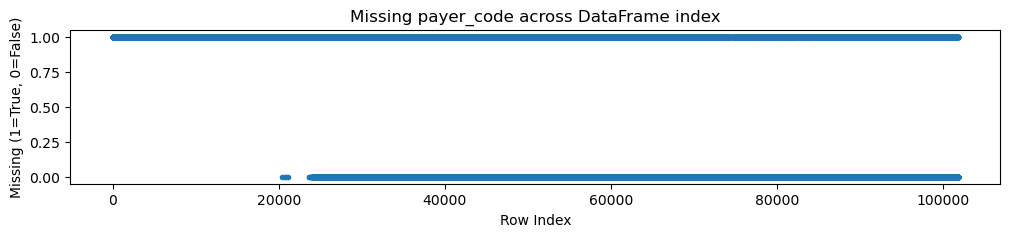

```python
# Create a boolean mask for missing payer_code
is_missing = (raw_data['payer_code'] == '?').astype(int)

plt.figure(figsize=(12, 2))
plt.plot(is_missing.values, marker='.', linestyle='None')
plt.title('Missing payer_code across DataFrame index')
plt.xlabel('Row Index')
plt.ylabel('Missing (1=True, 0=False)')
plt.show()
```

```python
# Check if encounter_id is monotonically increasing
is_monotonic = raw_data['encounter_id'].is_monotonic_increasing
print(f"Is encounter_id monotonically increasing? {is_monotonic}")

# Find where encounter_id decreases
decreases = raw_data['encounter_id'].diff().dropna() < 0
if decreases.any():
    print("Encounter_id decreases at the following indexes:")
    print(decreases[decreases].index.tolist())
else:
    print("Encounter_id never decreases; it is always increasing or constant.")
```

```
Is encounter_id monotonically increasing? False
Encounter_id decreases at the following indexes:
[1, 2, 4, 8]
```

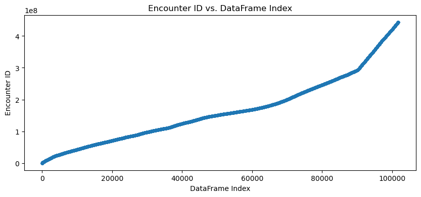

```python
plt.figure(figsize=(10, 4))
plt.plot(raw_data.index, raw_data['encounter_id'], marker='.', linestyle='None')
plt.xlabel('DataFrame Index')
plt.ylabel('Encounter ID')
plt.title('Encounter ID vs. DataFrame Index')
plt.show()
```

```python
# Define the threshold
threshold = 72091308

# Subset the data for encounter_id below the threshold
subset = raw_data[raw_data['encounter_id'] < threshold]

# Check if all payer_code values in this subset are missing ('?')
all_missing = (subset['payer_code'] == '?').all()

print(f"All encounter_id < {threshold} have missing payer_code: {all_missing}")

# Optionally, count how many are not missing (should be 0 if all_missing is True)
not_missing_count = (subset['payer_code'] != '?').sum()
print(f"Number of encounter_id < {threshold} with recorded payer_code: {not_missing_count}")
```

```
All encounter_id < 72091308 have missing payer_code: True
Number of encounter_id < 72091308 with recorded payer_code: 0
```

```python
# Find the first index where payer_code is not missing
first_recorded_index = raw_data[raw_data['payer_code'] != '?'].index[0]

# Count how many payer_code values are missing before this index
missing_before = (raw_data.loc[:first_recorded_index - 1, 'payer_code'] == '?').sum()
print(f"Number of missing payer_code values before first recorded index ({first_recorded_index}): {missing_before}")

# For completeness, check total missing
total_missing = (raw_data['payer_code'] == '?').sum()
print(f"Total missing payer_code values: {total_missing}")

# And after the first recorded index
missing_after = (raw_data.loc[first_recorded_index:, 'payer_code'] == '?').sum()
print(f"Number of missing payer_code values after first recorded index: {missing_after}")
```

```
Number of missing payer_code values before first recorded index (20446): 20446
Total missing payer_code values: 40256
Number of missing payer_code values after first recorded index: 19810
```

payer_code has ~40000 missing values and just over half of those from encounter IDs smaller than 72091308. No smaller encounter IDs have payer_code values recorded, i.e. all indexes in the dataset from 0 to 20445 are missing payer_code. In the last ~80000 indexes, there doesn't appear to be a pattern. I believe those are missing completely at random.

Because the missing category in payer_code accounts for the highest proportion of any one category, it makes more sense to me to make it it's own Unknown category rather than imputing with the next most frequent category or any alternative method.

#### Examine Missing: `medical_specialty`

```python
# Get the value counts for the column
counts = raw_data['medical_specialty'].value_counts()
print(counts)

# Count how many categories have < 10 observations
num_singletons = (counts < 10).sum()

print(f"Number of categories in 'medical_specialty' with fewer than 10 observations: {num_singletons} out of {len(counts)}")
```

```
medical_specialty
?                                49949
InternalMedicine                 14635
Emergency/Trauma                  7565
Family/GeneralPractice            7440
Cardiology                        5352
                                 ...
SportsMedicine                       1
Speech                               1
Perinatology                         1
Neurophysiology                      1
Pediatrics-InfectiousDiseases        1
Name: count, Length: 73, dtype: int64
Number of categories in 'medical_specialty' with fewer than 10 observations: 20 out of 73
```

By far, the largest category within medical_specialty are ?, nearly 50% (50K records) of the data. The next largest category is internal medicine with 14.6K.

I think the most prudent thing would be to report these as Unknown. Rather than trying to impute with the next most frequent category or fit a model to impute. I didn't see any pattern in these missing values.

I also prefer to avoid grouping the categories. It becomes a judgement call on how to best group the categories. For example, is it better to group all surgical together or group the pediatric surgery with the rest of pediatrics. For now, I prefer to leave them separate, even though many have fewer then .01% of the observations.

#### Check for Zero Variance Columns

```python
# Find columns with only one unique value (zero variance)
zero_var_cols = [col for col in raw_data.columns if raw_data[col].nunique(dropna=False) == 1]

print("Columns with zero variance:")
print(zero_var_cols)

print(raw_data[zero_var_cols].value_counts())
```

```
Columns with zero variance:
['examide', 'citoglipton']
examide  citoglipton
No       No             101766
Name: count, dtype: int64
```

Examide and Citoglipton are both columns with only one value, 'No'. Since they don't add any information to the analysis, I will drop them.

#### Visualize Missing Data

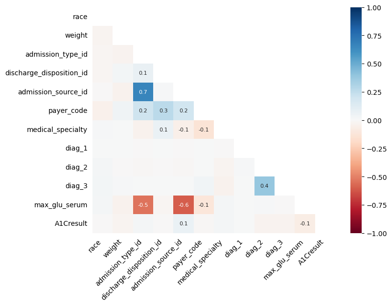

```python
missing_df = raw_data.copy()

missing_df = missing_df.replace('?', np.nan)

# List of columns to check
cols_to_check = ['admission_type_id', 'discharge_disposition_id', 'admission_source_id']

# Dictionary of values to replace for each column
replace_values = {
    'admission_type_id': [5, 6, 8],  # Not Available, NULL, Not Mapped
    'discharge_disposition_id': [18, 25],  # NULL, Not Mapped
    'admission_source_id': [9, 17, 20]  # Not Available, NULL, Not Mapped
}

for col, vals in replace_values.items():
    missing_df.loc[missing_df[col].isin(vals), col] = np.nan

import missingno as msno
# Visualize missing data as a heatmap
msno.heatmap(missing_df, fontsize=10, figsize=(8, 6))
# plt.savefig(f'plots/missing_heatmap.png')
plt.show()
```

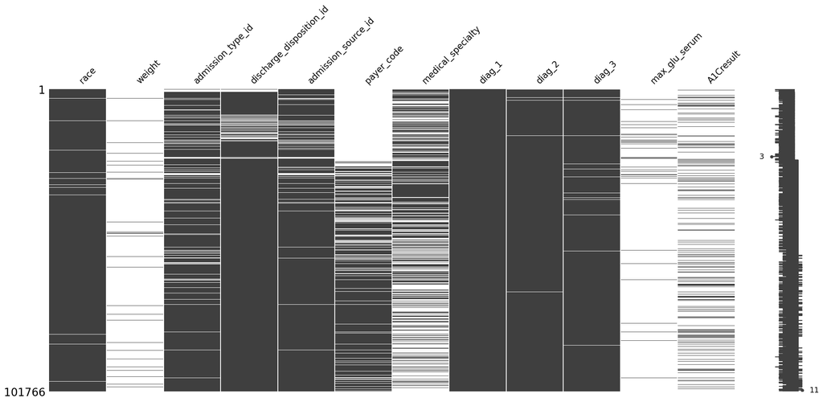

```python
# Visualize missing data as a matrix
msno.matrix(missing_df.loc[:, missing_df.isnull().any()])
# plt.savefig(f'plots/missing_matrix.png')
plt.show()
```

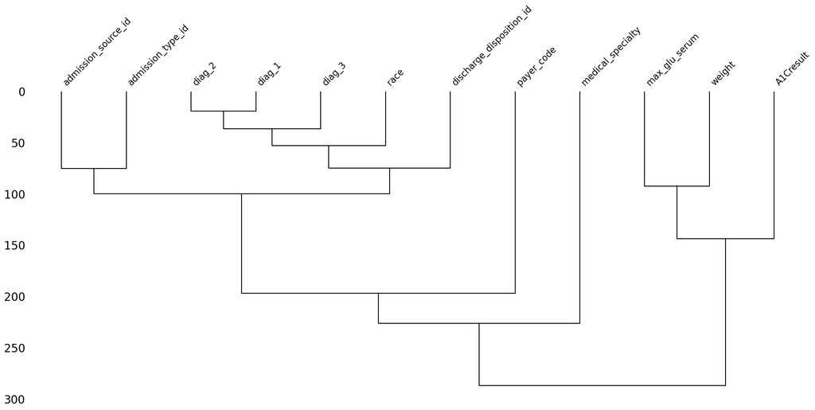

```python
# Visualize dendrogram for missingness correlations
msno.dendrogram(missing_df.loc[:, missing_df.isnull().any()])
# plt.savefig(f'plots/missing_dendrogram.png')
plt.show()
```

### Modify Datatypes

#### Integer Coded Categorical Variables

```python
# Make a copy of the dataset for modification / imputation
imputed_data = raw_data.copy()
```

```python
imputed_data['admission_type_id'].value_counts()
```

```
admission_type_id
1    53990
3    18869
2    18480
6     5291
5     4785
8      320
7       21
4       10
Name: count, dtype: int64
```

```python
# Create a dictionary mapping admission_type_id to their descriptions
admission_type_map = {
    1: 'Emergency',
    2: 'Urgent',
    3: 'Elective',
    4: 'Newborn',
    5: 'Not Available',
    6: 'NULL',
    7: 'Trauma Center',
    8: 'Not Mapped'
}

# Map the values using the dictionary
imputed_data['admission_type_id'] = imputed_data['admission_type_id'].map(admission_type_map)


print(imputed_data['admission_type_id'].dtype)
print(imputed_data['admission_type_id'].value_counts())
```

```
object
admission_type_id
Emergency        53990
Elective         18869
Urgent           18480
NULL              5291
Not Available     4785
Not Mapped         320
Trauma Center       21
Newborn             10
Name: count, dtype: int64
```

```python
# Create a mask for missing race values
missing_admissiontype_mask = imputed_data['admission_type_id'] == 'NULL'

# Create a function to compare distributions
def compare_distributions(df, column, missing_mask):
    # Get distribution for missing race
    missing_dist = df[missing_mask][column].value_counts(normalize=True) * 100

    # Get overall distribution
    overall_dist = df[column].value_counts(normalize=True) * 100

    # Create comparison DataFrame
    comparison = pd.DataFrame({
        'NULL admissionType %': missing_dist,
        'Overall %': overall_dist,
        'Difference %': (missing_dist - overall_dist)
    }).fillna(0)

    return comparison

# Compare distributions for different variables
print("\nRace Distribution Comparison:")
print(compare_distributions(imputed_data, 'race', missing_admissiontype_mask))
print("Gender Distribution Comparison:")
print(compare_distributions(imputed_data, 'gender', missing_admissiontype_mask))
print("\nAge Distribution Comparison:")
print(compare_distributions(imputed_data, 'age', missing_admissiontype_mask))
print("\nAdmission Source Distribution Comparison:")
print(compare_distributions(imputed_data, 'admission_source_id', missing_admissiontype_mask))
print("\nPayer Code Distribution Comparison:")
print(compare_distributions(imputed_data, 'payer_code', missing_admissiontype_mask))
print("\nMedical Specialty Distribution Comparison:")
med_sp_comparison = compare_distributions(imputed_data, 'medical_specialty', missing_admissiontype_mask)
print(med_sp_comparison[abs(med_sp_comparison['Difference %']) > 5]) # Filter for differences greater than 10%
```

```
Race Distribution Comparison:
                 NULL admissionType %  Overall %  Difference %
race
?                            1.247401   2.233555     -0.986154
AfricanAmerican             12.341712  18.876639     -6.534926
Asian                        1.077301   0.629876      0.447425
Caucasian                   78.794179  74.778413      4.015766
Hispanic                     4.517105   2.001651      2.515454
Other                        2.022302   1.479866      0.542436
Gender Distribution Comparison:
                 NULL admissionType %  Overall %  Difference %
gender
Female                      51.578152  53.758623     -2.180471
Male                        48.421848  46.238429      2.183419
Unknown/Invalid              0.000000   0.002948      0.000000

Age Distribution Comparison:
          NULL admissionType %  Overall %  Difference %
age
[70-80)              27.631828  25.615628      2.016200
[60-70)              21.961822  22.092840     -0.131018
[50-60)              17.501418  16.956547      0.544870
[80-90)              14.685315  16.898571     -2.213257
[40-50)               9.809110   9.516931      0.292179
[30-40)               3.969004   3.709490      0.259514
[90-100)              2.135702   2.744532     -0.608829
[20-30)               1.341901   1.628245     -0.286344
[10-20)               0.699301   0.679009      0.020292
[0-10)                0.264600   0.158206      0.106394

Admission Source Distribution Comparison:
                     NULL admissionType %  Overall %  Difference %
admission_source_id
1                               11.245511  29.051943    -17.806431
2                                0.472500   1.084842     -0.612341
3                                0.056700   0.183755     -0.127055
4                                0.831601   3.131694     -2.300093
5                                0.321300   0.840163     -0.518862
6                                0.094500   2.224712     -2.130211
7                               31.014931  56.496276    -25.481345
```

[output cut: 26 more lines]

```
OT                        0.0000   0.093351      0.000000
PO                        0.0000   0.581727      0.000000
SI                        0.0000   0.054046      0.000000
SP                        0.0189   4.920111     -4.901211
UN                        0.0189   2.405519     -2.386619
WC                        0.0000   0.132657      0.000000

Medical Specialty Distribution Comparison:
                        NULL admissionType %  Overall %  Difference %
medical_specialty
?                                  25.704026  49.082208    -23.378182
Cardiology                         14.987715   5.259124      9.728591
Emergency/Trauma                    0.434700   7.433720     -6.999020
Family/GeneralPractice             13.400113   7.310890      6.089224
InternalMedicine                   25.533926  14.381031     11.152895
```

Just over 5% of the dataset has an `admission_type_id` of `NULL`. There seem to be some patterns in the data among rows where admission_type_id is null:

- The proportion of Emergency Room admissions is 25% lower than in the overall dataset. Emergency Room admissions are less likely to have a NULL admission type.
- The proportion of admission source NULL (17) is 49% higher than in the overall dataset. If admission type is NULL, it’s much more likely that admission source is also NULL.
- The proportion with ? medical specialty is 23% lower than overall. Patients with ? medical specialty are less likely to have a NULL admission type.
- The proportion with ? payer code is 60% higher than overall. If admission type is NULL, it’s much more likely that payer code is also ?. So, I would like to look at the overlap between NULL admission type, NULL admission source and ? payer code.

```python
# Create boolean masks for each missing/unknown field
missing_admission_type = imputed_data['admission_type_id'] == 'NULL'
missing_admission_source = imputed_data['admission_source_id'] == 17  # Assuming 17 is the NULL code
missing_payer_code = imputed_data['payer_code'] == '?'

# Create a DataFrame with these masks
missing_combinations = pd.DataFrame({
    'Missing Admission Type': missing_admission_type,
    'Missing Admission Source': missing_admission_source,
    'Missing Payer Code': missing_payer_code
})

# Count the number of observations for each combination
combination_counts = missing_combinations.value_counts().sort_index(ascending=False)

print("Count of observations for each combination of missing/unknown fields:")
print(combination_counts)
```

```
Count of observations for each combination of missing/unknown fields:
Missing Admission Type  Missing Admission Source  Missing Payer Code
True                    True                      True                   2960
                        False                     True                   2327
                                                  False                     4
False                   True                      True                   2089
                                                  False                  1732
                        False                     True                  32880
                                                  False                 59774
Name: count, dtype: int64
```

It looks like the NULL values for admission type are more likely to be missing if payer code is also missing (all but 4 of the observations), so I believe these are MAR.

```python
# Change the datatype from int to object
imputed_data['admission_source_id'] = imputed_data['admission_source_id'].astype('object')
print(imputed_data['admission_source_id'].dtype)
print(imputed_data['admission_source_id'][:10])
print(sorted(imputed_data['admission_source_id'].unique()))
# no 12, 15 (not available), 18, 19, 21 (unknown/invalid), 23-26

imputed_data['discharge_disposition_id'] = imputed_data['discharge_disposition_id'].astype('object')
print(imputed_data['discharge_disposition_id'].dtype)
print(imputed_data['discharge_disposition_id'][:10])
print(sorted(imputed_data['discharge_disposition_id'].unique()))
# no 21, 26 (unknown/invalid), 29-30
```

```
object
0    1
1    7
2    7
3    7
4    7
5    2
6    2
7    7
8    4
9    4
Name: admission_source_id, dtype: object
[1, 2, 3, 4, 5, 6, 7, 8, 9, 10, 11, 13, 14, 17, 20, 22, 25]
object
0    25
1     1
2     1
3     1
4     1
5     1
6     1
7     1
8     1
9     3
Name: discharge_disposition_id, dtype: object
[1, 2, 3, 4, 5, 6, 7, 8, 9, 10, 11, 12, 13, 14, 15, 16, 17, 18, 19, 20, 22, 23, 24, 25, 27, 28]
```

```python
imputed_data['admission_source_id'].value_counts()
```

```
admission_source_id
7     57494
1     29565
17     6781
4      3187
6      2264
2      1104
5       855
3       187
20      161
9       125
8        16
22       12
10        8
14        2
11        2
25        2
13        1
Name: count, dtype: int64
```

```python
# Find all indexes where admission_source_id is 'Not Mapped' (code 20)
not_mapped_mask = raw_data['admission_source_id'] == 20
not_mapped_indexes = raw_data.index[not_mapped_mask]

if not not_mapped_indexes.empty:
    start_idx = not_mapped_indexes[0]
    group_end_idx = not_mapped_indexes[-2]
    end_idx = not_mapped_indexes[-1]
    print(f"'Not Mapped' admission_source_id starts at index: {start_idx}")
    print(f"'Not Mapped' admission_source_id grouping ends at index: {group_end_idx}")
    print(f"'Not Mapped' admission_source_id ends at index: {end_idx}")
```

```
'Not Mapped' admission_source_id starts at index: 469
'Not Mapped' admission_source_id grouping ends at index: 5854
'Not Mapped' admission_source_id ends at index: 69404
```

For values in admission id that could be considered missing, (17 = NULL, 6781; 20 = Not Mapped, 161) There are fewer than 7000 overall, with the vast majority of those being labeled as NULL and the rest Not Mapped. These could be grouped or imputed with the mode (emergency room), though as they are already labeled with integer categories, I think it is best to leave them as is. The not mapped values appear to be primarily arranged in the within the first 6000 observations of the dataset with one exception. Aside from that, I don't see any additional pattern. I also cannot find a pattern within the NULL values.

```python
imputed_data['discharge_disposition_id'].value_counts()
```

```
discharge_disposition_id
1     60234
3     13954
6     12902
18     3691
2      2128
22     1993
11     1642
5      1184
25      989
4       815
7       623
23      412
13      399
14      372
28      139
8       108
15       63
24       48
9        21
17       14
16       11
19        8
10        6
27        5
12        3
20        2
Name: count, dtype: int64
```

### Impute Missing Data

```python
# Check the imputed data shape first
print(imputed_data.shape)

# Drop the weight, examide, and citoglipton columns
imputed_data = imputed_data.drop(columns=['weight', 'examide', 'citoglipton'])
print(imputed_data.shape)

# Replace NaN with 'untested' in max_glu_serum and A1Cresult
imputed_data = imputed_data.fillna({
    'max_glu_serum': 'untested',
    'A1Cresult': 'untested'
})
print(imputed_data['max_glu_serum'].value_counts())
print(imputed_data['A1Cresult'].value_counts())
print(imputed_data[['max_glu_serum', 'A1Cresult']].isna().sum())

# Replace '?' with 'Unreported' in race
imputed_data['race'] = imputed_data['race'].replace('?', 'Unreported')
print(imputed_data['race'].value_counts())

# Replace '?' with 'Unknown' in payer_code
imputed_data['payer_code'] = imputed_data['payer_code'].replace('?', 'Unknown')
print(imputed_data['payer_code'].value_counts())

# Replace '?' with 'Unknown' in medical_specialty
imputed_data['medical_specialty'] = imputed_data['medical_specialty'].replace('?', 'Unknown')
print(imputed_data['medical_specialty'].value_counts())

# Remove the row with no diagnosis codes (index=87181, encounter_id=277875756)
# also could have imputed diag_1 with the mode
print(imputed_data.shape)
imputed_data = imputed_data.drop(index=87181)
print(imputed_data.shape)
```

```
(101766, 50)
(101766, 47)
max_glu_serum
untested    96420
Norm         2597
>200         1485
>300         1264
Name: count, dtype: int64
A1Cresult
untested    84748
>8           8216
Norm         4990
>7           3812
Name: count, dtype: int64
max_glu_serum    0
A1Cresult        0
dtype: int64
race
Caucasian          76099
AfricanAmerican    19210
Unreported          2273
Hispanic            2037
Other               1506
Asian                641
Name: count, dtype: int64
payer_code
Unknown    40256
MC         32439
HM          6274
SP          5007
BC          4655
MD          3532
CP          2533
UN          2448
CM          1937
OG          1033
PO           592
DM           549
CH           146
WC           135
OT            95
MP            79
SI            55
FR             1
Name: count, dtype: int64
medical_specialty
Unknown                          49949
InternalMedicine                 14635
Emergency/Trauma                  7565
Family/GeneralPractice            7440
Cardiology                        5352
                                 ...
SportsMedicine                       1
Speech                               1
Perinatology                         1
Neurophysiology                      1
Pediatrics-InfectiousDiseases        1
Name: count, Length: 73, dtype: int64
(101766, 47)
(101765, 47)
```

### Summary Statistics

```python
# Summary statistics of the numerical features

# Calculate basic statistics
desc = imputed_data .describe()  # Includes count, mean, std, 5-number summary
modes_num = imputed_data.mode(numeric_only=True).iloc[0]  # Get the first mode for each column
variances = imputed_data.var(numeric_only=True)
ranges = imputed_data.max(numeric_only=True) - imputed_data.min(numeric_only=True)
skewness = imputed_data.skew(numeric_only=True)
kurtosis = imputed_data.kurt(numeric_only=True)

# Create a summary DataFrame
num_stats_df = pd.DataFrame({
    'Count': desc.loc['count'],
    'Mean': desc.loc['mean'],
    'Std': desc.loc['std'],
    'Min': desc.loc['min'],
    '25%': desc.loc['25%'],
    'Median': desc.loc['50%'],
    '75%': desc.loc['75%'],
    'Max': desc.loc['max'],
    'Range': ranges,
    'Variance': variances,
    'Mode': modes_num,
    'Skewness': skewness, # Measure of asymmetry of the distribution
    'Kurtosis': kurtosis # Measure of the "tailedness" of the distribution
})

# Rearrange and clean up for better presentation
num_stats_df = num_stats_df[['Count', 'Mean', 'Std', 'Variance', 'Min', '25%', 'Median', '75%', 'Max', 'Range', 'Mode', 'Skewness', 'Kurtosis']]
num_stats_df.reset_index(inplace=True)  # Optional: Keep variable names as a column
num_stats_df.rename(columns={'index': 'Variable'}, inplace=True)

# Display the final DataFrame
num_stats_df
```

|  | Variable | Count | Mean | Std | Variance | Min | 25% | Median | 75% | Max | Range | Mode | Skewness | Kurtosis |
| --- | --- | --- | --- | --- | --- | --- | --- | --- | --- | --- | --- | --- | --- | --- |
| 0 | encounter_id | 101765.0 | 1.652005e+08 | 1.026402e+08 | 1.053501e+16 | 12522.0 | 84960072.0 | 152388294.0 | 230267634.0 | 443867222.0 | 443854700 | 12522.0 | 0.699170 | -0.102015 |
| 1 | patient_nbr | 101765.0 | 5.433087e+07 | 3.869626e+07 | 1.497401e+15 | 135.0 | 23413248.0 | 45505143.0 | 87546186.0 | 189502619.0 | 189502484 | 88785891.0 | 0.471271 | -0.347365 |
| 2 | time_in_hospital | 101765.0 | 4.395961e+00 | 2.985111e+00 | 8.910889e+00 | 1.0 | 2.0 | 4.0 | 6.0 | 14.0 | 13 | 3.0 | 1.134025 | 0.850304 |
| 3 | num_lab_procedures | 101765.0 | 4.309605e+01 | 1.967402e+01 | 3.870669e+02 | 1.0 | 31.0 | 44.0 | 57.0 | 132.0 | 131 | 1.0 | -0.236526 | -0.245039 |
| 4 | num_procedures | 101765.0 | 1.339724e+00 | 1.705814e+00 | 2.909802e+00 | 0.0 | 0.0 | 1.0 | 2.0 | 6.0 | 6 | 0.0 | 1.316422 | 0.857104 |
| 5 | num_medications | 101765.0 | 1.602186e+01 | 8.127604e+00 | 6.605794e+01 | 1.0 | 10.0 | 15.0 | 20.0 | 81.0 | 80 | 13.0 | 1.326660 | 3.468086 |
| 6 | number_outpatient | 101765.0 | 3.693608e-01 | 1.267271e+00 | 1.605975e+00 | 0.0 | 0.0 | 0.0 | 0.0 | 42.0 | 42 | 0.0 | 8.832918 | 147.906404 |
| 7 | number_emergency | 101765.0 | 1.978382e-01 | 9.304766e-01 | 8.657868e-01 | 0.0 | 0.0 | 0.0 | 0.0 | 76.0 | 76 | 0.0 | 22.855479 | 1191.675857 |
| 8 | number_inpatient | 101765.0 | 6.355623e-01 | 1.262869e+00 | 1.594838e+00 | 0.0 | 0.0 | 0.0 | 1.0 | 21.0 | 21 | 0.0 | 3.614134 | 20.719244 |
| 9 | number_diagnoses | 101765.0 | 7.422631e+00 | 1.933595e+00 | 3.738789e+00 | 1.0 | 6.0 | 8.0 | 9.0 | 16.0 | 15 | 9.0 | -0.876780 | -0.078976 |

### Encoding and Scaling

#### Diagnosis Codes

```python
# Confirm whether encounter_id is unique
duplicate_check = imputed_data['encounter_id'].duplicated().any() # returns boolean
duplicate_check
```

```
np.False_
```

```python
diag_cols = ['diag_1', 'diag_2', 'diag_3']

# Reshape from wide to long format
diag_long_df = imputed_data.melt(
    id_vars='encounter_id',
    value_vars=diag_cols,
    value_name='diagnosis_code'
)

# Preview
print(diag_long_df.head())
print(diag_long_df[(diag_long_df['encounter_id'] == 2278392) | (diag_long_df['encounter_id'] == 149190)])
print(diag_long_df.shape)
```

```
   encounter_id variable diagnosis_code
0       2278392   diag_1         250.83
1        149190   diag_1            276
2         64410   diag_1            648
3        500364   diag_1              8
4         16680   diag_1            197
        encounter_id variable diagnosis_code
0            2278392   diag_1         250.83
1             149190   diag_1            276
101765       2278392   diag_2              ?
101766        149190   diag_2         250.01
203530       2278392   diag_3              ?
203531        149190   diag_3            255
(305295, 3)
```

```python
# Remove rows where diagnosis code is '?'
diag_long_df = diag_long_df[diag_long_df['diagnosis_code'] != '?']
print(diag_long_df.shape)

# Check that with summary of ?s from earlier
questionmark_summary.loc[['diag_1', 'diag_2', 'diag_3'], '? Count'].sum() == 305298 - diag_long_df.shape[0]
```

```
(303496, 3)
```

```
np.True_
```

```python
# Group by encounter and diagnosis code, and count
diag_counts_df = (
    diag_long_df
    .groupby(['encounter_id', 'diagnosis_code'])
    .size()
    .unstack(fill_value=0)
)

print(diag_counts_df.head())
print(diag_counts_df.columns)
print(diag_counts_df.shape)

diag_counts_df.loc[2278392][diag_counts_df.loc[2278392] >= 1].index.tolist() # sanity check
```

```
diagnosis_code  10  11  110  111  112  114  115  117  122  123  ...  V64  V65  \
encounter_id                                                    ...
12522            0   0    0    0    0    0    0    0    0    0  ...    0    0
15738            0   0    0    0    0    0    0    0    0    0  ...    0    0
16680            0   0    0    0    0    0    0    0    0    0  ...    0    0
28236            0   0    0    0    0    0    0    0    0    0  ...    0    0
35754            0   0    0    0    0    0    0    0    0    0  ...    0    0

diagnosis_code  V66  V67  V69  V70  V71  V72  V85  V86
encounter_id
12522             0    0    0    0    0    0    0    0
15738             0    0    0    0    0    0    0    0
16680             0    0    0    0    0    0    0    0
28236             0    0    0    0    0    0    0    0
35754             0    0    0    0    0    0    0    0

[5 rows x 915 columns]
Index(['10', '11', '110', '111', '112', '114', '115', '117', '122', '123',
       ...
       'V64', 'V65', 'V66', 'V67', 'V69', 'V70', 'V71', 'V72', 'V85', 'V86'],
      dtype='object', name='diagnosis_code', length=915)
(101765, 915)
```

```
['250.83']
```

```python
# Add 'diag_' prefix to all column names
diag_counts_df.columns = ['diag_' + str(col) for col in diag_counts_df.columns]

# Preview the result
print(diag_counts_df.head())
print(diag_counts_df.columns)
```

```
              diag_10  diag_11  diag_110  diag_111  diag_112  diag_114  \
encounter_id
12522               0        0         0         0         0         0
15738               0        0         0         0         0         0
16680               0        0         0         0         0         0
28236               0        0         0         0         0         0
35754               0        0         0         0         0         0

              diag_115  diag_117  diag_122  diag_123  ...  diag_V64  diag_V65  \
encounter_id                                          ...
12522                0         0         0         0  ...         0         0
15738                0         0         0         0  ...         0         0
16680                0         0         0         0  ...         0         0
28236                0         0         0         0  ...         0         0
35754                0         0         0         0  ...         0         0

              diag_V66  diag_V67  diag_V69  diag_V70  diag_V71  diag_V72  \
encounter_id
12522                0         0         0         0         0         0
15738                0         0         0         0         0         0
16680                0         0         0         0         0         0
28236                0         0         0         0         0         0
35754                0         0         0         0         0         0

              diag_V85  diag_V86
encounter_id
12522                0         0
15738                0         0
16680                0         0
28236                0         0
35754                0         0

[5 rows x 915 columns]
Index(['diag_10', 'diag_11', 'diag_110', 'diag_111', 'diag_112', 'diag_114',
       'diag_115', 'diag_117', 'diag_122', 'diag_123',
       ...
       'diag_V64', 'diag_V65', 'diag_V66', 'diag_V67', 'diag_V69', 'diag_V70',
       'diag_V71', 'diag_V72', 'diag_V85', 'diag_V86'],
      dtype='object', length=915)
```

#### Define Category Order for Clean Visualization

I decided to not use a midpoint for each age range and convert to numeric. This assumes a linear relationship between age and log odd of readmittance that I'd rather not make. I could've have also made this ordinal but I think I'll stick with one-hot encoding and see how it goes.

```python
# Define the correct order for each variable for clean visualization
readmit_order = ['<30', '>30', 'NO']
drug_order = ['No', 'Down', 'Steady', 'Up']
max_glu_serum_order = ['Untested', 'Norm', '>200', '>300']
a1cresult_order = ['Untested', 'Norm', '>7', '>8']
age_order = ['[0-10)', '[10-20)', '[20-30)', '[30-40)', '[40-50)',
             '[50-60)', '[60-70)', '[70-80)', '[80-90)', '[90-100)']

# List of drug-related variables
drug_columns = ['metformin', 'repaglinide', 'nateglinide', 'chlorpropamide', 'glimepiride',
                'acetohexamide', 'glipizide', 'glyburide', 'tolbutamide', 'tolazamide',
                'pioglitazone', 'rosiglitazone', 'troglitazone', 'acarbose', 'miglitol',
                'insulin', 'glyburide-metformin', 'glipizide-metformin',
                'metformin-rosiglitazone', 'metformin-pioglitazone', 'glimepiride-pioglitazone']

# Reorder categories in the DataFrame
imputed_data['readmitted'] = pd.Categorical(imputed_data['readmitted'], categories=readmit_order, ordered=True)
imputed_data['max_glu_serum'] = pd.Categorical(imputed_data['max_glu_serum'], categories=max_glu_serum_order, ordered=True)
imputed_data['A1Cresult'] = pd.Categorical(imputed_data['A1Cresult'], categories=a1cresult_order, ordered=True)
imputed_data['age'] = pd.Categorical(imputed_data['age'], categories=age_order, ordered=True)
```

#### Split Data into X and y

```python
# Remove target (split into X and y, for plotting with y later)
print(imputed_data.shape)
X_no_diag = imputed_data.copy().drop(columns=['diag_1', 'diag_2', 'diag_3', 'readmitted'])
y = imputed_data['readmitted']
print(X_no_diag.shape, y.shape)
```

```
(101765, 47)
(101765, 43) (101765,)
```

#### One-hot encoding categorical variables

```python
# Handle categorical variables with one-hot encoding
categorical_cols_to_encode = X_no_diag.select_dtypes(include=['object', 'category']).columns
print(categorical_cols_to_encode)

X_no_diag_encoded = pd.get_dummies(X_no_diag, columns=categorical_cols_to_encode, drop_first=False)
print(X_no_diag_encoded.shape)
```

```
Index(['race', 'gender', 'age', 'admission_type_id',
       'discharge_disposition_id', 'admission_source_id', 'payer_code',
       'medical_specialty', 'max_glu_serum', 'A1Cresult', 'metformin',
       'repaglinide', 'nateglinide', 'chlorpropamide', 'glimepiride',
       'acetohexamide', 'glipizide', 'glyburide', 'tolbutamide',
       'pioglitazone', 'rosiglitazone', 'acarbose', 'miglitol', 'troglitazone',
       'tolazamide', 'insulin', 'glyburide-metformin', 'glipizide-metformin',
       'glimepiride-pioglitazone', 'metformin-rosiglitazone',
       'metformin-pioglitazone', 'change', 'diabetesMed'],
      dtype='object')
(101765, 252)
```

#### Check for Outliers Prior to Choosing a Scaler

```python
# Calculate IQR and outlier bounds
num_stats_df['IQR'] = num_stats_df['75%'] - num_stats_df['25%']  # Interquartile Range
num_stats_df['Lower_IQR_Bound'] = num_stats_df['25%'] - 1.5 * num_stats_df['IQR']
num_stats_df['Upper_IQR_Bound'] = num_stats_df['75%'] + 1.5 * num_stats_df['IQR']

outliers = {} # Empty dictionary to store outliers for each variable
total_rows = len(X_no_diag_encoded)

for var in X_no_diag_encoded.select_dtypes(include='number').columns:
    # Get lower and upper bounds for the variable
    lower_bound = num_stats_df.loc[num_stats_df['Variable'] == var, 'Lower_IQR_Bound'].values[0]
    upper_bound = num_stats_df.loc[num_stats_df['Variable'] == var, 'Upper_IQR_Bound'].values[0]

    # Find outliers
    outliers[var] = X_no_diag_encoded[(X_no_diag_encoded[var] < lower_bound) | (X_no_diag_encoded[var] > upper_bound)][var]

# Summarize outliers
outlier_counts = {var: len(outlier_values) for var, outlier_values in outliers.items()}
outlier_proportions = {var: round((count / total_rows) * 100, 2) for var, count in outlier_counts.items()}  # Convert to percentage and round

# Create a summary DataFrame
outliers_summary_df = pd.DataFrame({
    'Variable': outlier_counts.keys(),
    'Outlier Count': outlier_counts.values(),
    'Outlier Proportion (%)': outlier_proportions.values()  # Updated to percentage
})

outliers_summary_df
```

|  | Variable | Outlier Count | Outlier Proportion (%) |
| --- | --- | --- | --- |
| 0 | encounter_id | 0 | 0.00 |
| 1 | patient_nbr | 247 | 0.24 |
| 2 | time_in_hospital | 2252 | 2.21 |
| 3 | num_lab_procedures | 143 | 0.14 |
| 4 | num_procedures | 4954 | 4.87 |
| 5 | num_medications | 2557 | 2.51 |
| 6 | number_outpatient | 16739 | 16.45 |
| 7 | number_emergency | 11383 | 11.19 |
| 8 | number_inpatient | 7049 | 6.93 |
| 9 | number_diagnoses | 281 | 0.28 |

#### Get a List of Numeric Variables to Scale

```python
numeric_columns = X_no_diag_encoded.select_dtypes(include=['float64', 'int64']).columns
print(numeric_columns)
numeric_cols_to_scale = numeric_columns.drop(['encounter_id', 'patient_nbr'])
print(numeric_cols_to_scale)
```

```
Index(['encounter_id', 'patient_nbr', 'time_in_hospital', 'num_lab_procedures',
       'num_procedures', 'num_medications', 'number_outpatient',
       'number_emergency', 'number_inpatient', 'number_diagnoses'],
      dtype='object')
Index(['time_in_hospital', 'num_lab_procedures', 'num_procedures',
       'num_medications', 'number_outpatient', 'number_emergency',
       'number_inpatient', 'number_diagnoses'],
      dtype='object')
```

#### Visualize Numeric Variable Distributions

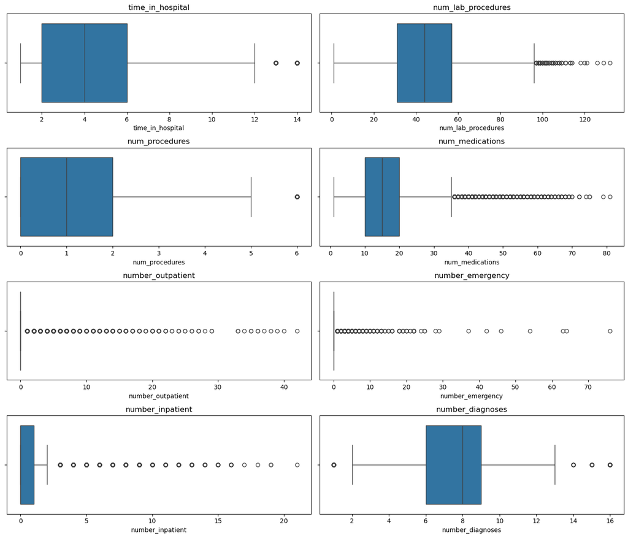

```python
cols = numeric_cols_to_scale
num_cols = len(cols)
n_cols = 2  # number of columns in the grid
n_rows = -(-num_cols // n_cols)  # ceil division

fig, axes = plt.subplots(n_rows, n_cols, figsize=(14, n_rows * 3))
axes = axes.flatten()  # flatten to make indexing easier

for i, col in enumerate(cols):
    sns.boxplot(x=X_no_diag_encoded[col], ax=axes[i])
    axes[i].set_title(col)

# Hide unused subplots
for j in range(i + 1, len(axes)):
    fig.delaxes(axes[j])

plt.tight_layout()
plt.show()
```

#### Scale the Numeric Variables

There are quite a few extreme outliers in some of the variables, so I will use Robust Scaler.

```python
# Standardize the dataset
scaler = RobustScaler() # Uses median and IQR to scale data, resistant to outliers

print(X_no_diag_encoded.describe())
scaled_array = scaler.fit_transform(X_no_diag_encoded[numeric_cols_to_scale])
X_no_diag_encoded[numeric_cols_to_scale] = scaled_array

print(X_no_diag_encoded.describe())
```

```
       encounter_id   patient_nbr  time_in_hospital  num_lab_procedures  \
count  1.017650e+05  1.017650e+05     101765.000000       101765.000000
mean   1.652005e+08  5.433087e+07          4.395961           43.096055
std    1.026402e+08  3.869626e+07          2.985111           19.674016
min    1.252200e+04  1.350000e+02          1.000000            1.000000
25%    8.496007e+07  2.341325e+07          2.000000           31.000000
50%    1.523883e+08  4.550514e+07          4.000000           44.000000
75%    2.302676e+08  8.754619e+07          6.000000           57.000000
max    4.438672e+08  1.895026e+08         14.000000          132.000000

       num_procedures  num_medications  number_outpatient  number_emergency  \
count   101765.000000    101765.000000      101765.000000     101765.000000
mean         1.339724        16.021864           0.369361          0.197838
std          1.705814         8.127604           1.267271          0.930477
min          0.000000         1.000000           0.000000          0.000000
25%          0.000000        10.000000           0.000000          0.000000
50%          1.000000        15.000000           0.000000          0.000000
75%          2.000000        20.000000           0.000000          0.000000
max          6.000000        81.000000          42.000000         76.000000

       number_inpatient  number_diagnoses
count     101765.000000     101765.000000
mean           0.635562          7.422631
std            1.262869          1.933595
min            0.000000          1.000000
25%            0.000000          6.000000
50%            0.000000          8.000000
75%            1.000000          9.000000
max           21.000000         16.000000
       encounter_id   patient_nbr  time_in_hospital  num_lab_procedures  \
count  1.017650e+05  1.017650e+05     101765.000000       101765.000000
mean   1.652005e+08  5.433087e+07          0.098990           -0.034767
std    1.026402e+08  3.869626e+07          0.746278            0.756693
min    1.252200e+04  1.350000e+02         -0.750000           -1.653846
25%    8.496007e+07  2.341325e+07         -0.500000           -0.500000
50%    1.523883e+08  4.550514e+07          0.000000            0.000000
75%    2.302676e+08  8.754619e+07          0.500000            0.500000
max    4.438672e+08  1.895026e+08          2.500000            3.384615

       num_procedures  num_medications  number_outpatient  number_emergency  \
count   101765.000000    101765.000000      101765.000000     101765.000000
mean         0.169862         0.102186           0.369361          0.197838
std          0.852907         0.812760           1.267271          0.930477
min         -0.500000        -1.400000           0.000000          0.000000
25%         -0.500000        -0.500000           0.000000          0.000000
50%          0.000000         0.000000           0.000000          0.000000
75%          0.500000         0.500000           0.000000          0.000000
max          2.500000         6.600000          42.000000         76.000000

       number_inpatient  number_diagnoses
count     101765.000000     101765.000000
mean           0.635562         -0.192456
std            1.262869          0.644532
min            0.000000         -2.333333
25%            0.000000         -0.666667
50%            0.000000          0.000000
75%            1.000000          0.333333
max           21.000000          2.666667
```

#### Add Count Encoded Diagnoses Codes Back into X

```python
# Join the count encoded diagnoses codes back into X by encounter_id

X = pd.merge(X_no_diag_encoded, diag_counts_df, on='encounter_id', how='left')

print(X.columns)
print(X.shape)
```

```
Index(['encounter_id', 'patient_nbr', 'time_in_hospital', 'num_lab_procedures',
       'num_procedures', 'num_medications', 'number_outpatient',
       'number_emergency', 'number_inpatient', 'number_diagnoses',
       ...
       'diag_V64', 'diag_V65', 'diag_V66', 'diag_V67', 'diag_V69', 'diag_V70',
       'diag_V71', 'diag_V72', 'diag_V85', 'diag_V86'],
      dtype='object', length=1167)
(101765, 1167)
```

#### Drop ID Variables

```python
X = X.drop(columns=['encounter_id', 'patient_nbr'])
print(X.shape)
```

```
(101765, 1165)
```

#### Double check for NaNs

```python
nan_rows = X[X.isnull().any(axis=1)]
# nan_rows.index
```

### Logistic Regression

```python
# Find the proportion of each response class for class_weights
print(imputed_data['readmitted'].value_counts()/imputed_data['readmitted'].count())
```

```
readmitted
NO     0.539115
>30    0.349285
<30    0.111600
Name: count, dtype: float64
```

```python
# Instantiate the model
log_reg_model = LogisticRegression(penalty='l2', max_iter=2000)

# StratifiedKFold for class balance in each fold
cv = StratifiedKFold(n_splits=5, shuffle=True, random_state=SEED)

param_grid = {
    'C': [0.01, 0.1, 0.2, 0.5, 1],  # inverse of regularization strength (C=1/lambda)
    'solver': ['saga', 'lbfgs']  # sag and saga are good for sparse data + multiclass and medium to larger datasets, use stochastic gradient descent
}

grid = GridSearchCV(
    log_reg_model,
    param_grid,
    cv=cv,
    scoring='f1_weighted',  # good for imbalanced data
    n_jobs=1,  # ResourceWarning and ChildProcessError for other n_jobs
    verbose=2
)

grid.fit(X, y)
```

[output not shown]

```
GridSearchCV(cv=StratifiedKFold(n_splits=5, random_state=13, shuffle=True),
             estimator=LogisticRegression(max_iter=2000), n_jobs=1,
             param_grid={'C': [0.01, 0.1, 0.2, 0.5, 1],
                         'solver': ['saga', 'lbfgs']},
             scoring='f1_weighted', verbose=2)
```

```python
print("Best parameters:", grid.best_params_)
print("Best score:", grid.best_score_)
```

```
Best parameters: {'C': 1, 'solver': 'saga'}
Best score: 0.539146080084533
```

```python
results_df = pd.DataFrame(grid.cv_results_)
results_df.to_csv("logreg_results.csv", index=False)
print(results_df[['param_C', 'param_solver', 'mean_test_score', 'mean_fit_time']])
```

```
   param_C param_solver  mean_test_score  mean_fit_time
0     0.01         saga         0.531554      75.424836
1     0.01        lbfgs         0.531603      64.213605
2     0.10         saga         0.537512     244.578987
3     0.10        lbfgs         0.537530     144.145418
4     0.20         saga         0.538247     370.274756
5     0.20        lbfgs         0.538533     119.087778
6     0.50         saga         0.539048     579.889493
7     0.50        lbfgs         0.538688     223.603400
8     1.00         saga         0.539146     748.544314
9     1.00        lbfgs         0.538744      56.051129
```

```python
# Instantiate the model
log_reg_model = LogisticRegression(penalty='l2', max_iter=2000)

# StratifiedKFold for class balance in each fold
cv = StratifiedKFold(n_splits=5, shuffle=True, random_state=SEED)

param_grid = {
    'C': [0.01, 0.1, 1, 10, 100],  # inverse of regularization strength (C=1/lambda)
    'solver': ['lbfgs', 'newton-cg']  # this dataset must not be large or sparse enough to not do well with lbfgs
}

grid2 = GridSearchCV(
    log_reg_model,
    param_grid,
    cv=cv,
    scoring='f1_weighted',  # good for imbalanced data
    verbose=2
)

grid2.fit(X, y)
```

[output not shown]

```
GridSearchCV(cv=StratifiedKFold(n_splits=5, random_state=13, shuffle=True),
             estimator=LogisticRegression(max_iter=2000),
             param_grid={'C': [0.01, 0.1, 1, 10, 100],
                         'solver': ['lbfgs', 'newton-cg']},
             scoring='f1_weighted', verbose=2)
```

```python
print("Best parameters:", grid2.best_params_)
print("Best score:", grid2.best_score_)

results_df2 = pd.DataFrame(grid2.cv_results_)
results_df2.to_csv("logreg_results2.csv", index=False)
print(results_df2[['param_C', 'param_solver', 'mean_test_score', 'mean_fit_time']])
```

```
Best parameters: {'C': 100, 'solver': 'newton-cg'}
Best score: 0.5392863325444271
   param_C param_solver  mean_test_score  mean_fit_time
0     0.01        lbfgs         0.531603      12.138684
1     0.01    newton-cg         0.531587      10.362579
2     0.10        lbfgs         0.537530      27.211283
3     0.10    newton-cg         0.537627      15.072440
4     1.00        lbfgs         0.538744      53.006567
5     1.00    newton-cg         0.539011      27.782905
6    10.00        lbfgs         0.538868      82.572455
7    10.00    newton-cg         0.539152      68.743516
8   100.00        lbfgs         0.538817      96.731810
9   100.00    newton-cg         0.539286      80.051180
```

lbfgs at c=1 seems like the best choice. While newton-cg is faster, lbfgs maybe be more robust to poor initialization and local minima. Therefore the improvement in F1 of ~0.04% may not be important. Additionally with the lbfgs solver, getting a 0.02% higher F1 with c=10 doesn't seem worth the extra computation time. Also, weaker regularization would make the model more prone to overfitting.

```python
# I forgot to tune class weights

log_reg_model = LogisticRegression(penalty='l2', solver='lbfgs', C=1, max_iter=2000)

cv = StratifiedKFold(n_splits=5, shuffle=True, random_state=SEED)

# Define class weights to try
class_weights = [
    'balanced',
    {'<30': 3, '>30': 1, 'NO': 1}, # Moderate boost for <30
    {'<30': 5, '>30': 1, 'NO': 1}, # Stronger boost for <30
    {'<30': 2, '>30': 1.5, 'NO': 1}, # Boost both <30 and >30
    {'<30': 1, '>30': 1, 'NO': 1} # Equal weights (baseline)
]

param_grid = {
    'class_weight': class_weights
}

grid3 = GridSearchCV(
    log_reg_model,
    param_grid,
    cv=cv,
    scoring='f1_weighted',  # good for imbalanced data
    verbose=2
)

grid3.fit(X, y)

print("Best parameters:", grid3.best_params_)
print("Best score:", grid3.best_score_)

results_df3 = pd.DataFrame(grid3.cv_results_)
results_df3.to_csv("logreg_results3.csv", index=False)
print(results_df3[['param_class_weight', 'mean_test_score', 'mean_fit_time']])
```

```
Fitting 5 folds for each of 5 candidates, totalling 25 fits
[CV] END ..............................class_weight=balanced; total time=  53.0s
[CV] END ..............................class_weight=balanced; total time=  58.3s
[CV] END ..............................class_weight=balanced; total time= 1.1min
[CV] END ..............................class_weight=balanced; total time= 1.0min
[CV] END ..............................class_weight=balanced; total time=  56.4s
[CV] END .........class_weight={'<30': 3, '>30': 1, 'NO': 1}; total time=  58.4s
[CV] END .........class_weight={'<30': 3, '>30': 1, 'NO': 1}; total time=  54.8s
[CV] END .........class_weight={'<30': 3, '>30': 1, 'NO': 1}; total time=  55.2s
[CV] END .........class_weight={'<30': 3, '>30': 1, 'NO': 1}; total time= 1.0min
[CV] END .........class_weight={'<30': 3, '>30': 1, 'NO': 1}; total time=  56.6s
[CV] END .........class_weight={'<30': 5, '>30': 1, 'NO': 1}; total time= 1.1min
[CV] END .........class_weight={'<30': 5, '>30': 1, 'NO': 1}; total time=  58.8s
[CV] END .........class_weight={'<30': 5, '>30': 1, 'NO': 1}; total time=  56.8s
[CV] END .........class_weight={'<30': 5, '>30': 1, 'NO': 1}; total time= 1.0min
[CV] END .........class_weight={'<30': 5, '>30': 1, 'NO': 1}; total time= 1.0min
[CV] END .......class_weight={'<30': 2, '>30': 1.5, 'NO': 1}; total time=  56.1s
[CV] END .......class_weight={'<30': 2, '>30': 1.5, 'NO': 1}; total time=  56.9s
[CV] END .......class_weight={'<30': 2, '>30': 1.5, 'NO': 1}; total time=  55.1s
[CV] END .......class_weight={'<30': 2, '>30': 1.5, 'NO': 1}; total time=  58.4s
[CV] END .......class_weight={'<30': 2, '>30': 1.5, 'NO': 1}; total time= 1.1min
[CV] END .........class_weight={'<30': 1, '>30': 1, 'NO': 1}; total time=  48.3s
[CV] END .........class_weight={'<30': 1, '>30': 1, 'NO': 1}; total time=  54.2s
[CV] END .........class_weight={'<30': 1, '>30': 1, 'NO': 1}; total time=  50.2s
[CV] END .........class_weight={'<30': 1, '>30': 1, 'NO': 1}; total time=  52.2s
[CV] END .........class_weight={'<30': 1, '>30': 1, 'NO': 1}; total time=  53.1s
Best parameters: {'class_weight': {'<30': 2, '>30': 1.5, 'NO': 1}}
Best score: 0.5529387366081652
                param_class_weight  mean_test_score  mean_fit_time
0                         balanced         0.519398      59.172297
1    {'<30': 3, '>30': 1, 'NO': 1}         0.521552      57.435571
2    {'<30': 5, '>30': 1, 'NO': 1}         0.439811      60.707789
3  {'<30': 2, '>30': 1.5, 'NO': 1}         0.552939      58.350861
4    {'<30': 1, '>30': 1, 'NO': 1}         0.538744      51.523065
```

Rather than using class_weight='balanced', which sets the weight of each class inversely proportional to its frequency in the data, I got the best weighted_F1 performance by giving more importance to the two less frequent classes but not as extreme as balanced class weight does given the proportion of each in the dataset ~11%: <30, ~35%: >30, ~54%: NO. I'm not sure if weighted_F1 is the best choice but it's probably okay.

```python
# Instantiate the model
final_model = LogisticRegression(penalty='l2', solver='lbfgs', C=1.0, class_weight='balanced', max_iter=2000)

# Cross-validation setup
cv = StratifiedKFold(n_splits=5, shuffle=True, random_state=SEED)
scoring = ['accuracy', 'precision_weighted', 'recall_weighted', 'f1_weighted']
cv_results = cross_validate(final_model, X, y, cv=cv, scoring=scoring, return_estimator=True)

# Mean and std dev of scores
mean_scores = {k: np.mean(v) for k, v in cv_results.items() if k.startswith('test_')}
std_scores = {k: np.std(cv_results[k]) for k in mean_scores.keys()}

print("\nCross-Validation Metrics (Mean ± SD):")
for k in mean_scores:
    print(f"{k}: {mean_scores[k]:.4f} ± {std_scores[k]:.4f}")

# Cross-validated predictions for confusion matrix and classification report
y_pred = cross_val_predict(final_model, X, y, cv=cv)
conf_matrix = confusion_matrix(y, y_pred)
report = classification_report(y, y_pred, target_names=readmit_order)
print("\nClassification Report:")
print(report)
```

```
Cross-Validation Metrics (Mean ± SD):
test_accuracy: 0.4991 ± 0.0026
test_precision_weighted: 0.5568 ± 0.0035
test_recall_weighted: 0.4991 ± 0.0026
test_f1_weighted: 0.5194 ± 0.0027

Classification Report:
              precision    recall  f1-score   support

         <30       0.19      0.43      0.27     11357
         >30       0.46      0.42      0.44     35545
          NO       0.69      0.57      0.62     54863

    accuracy                           0.50    101765
   macro avg       0.45      0.47      0.44    101765
weighted avg       0.56      0.50      0.52    101765
```

```python
# Label encode the string class labels
readmit_order = ['<30', '>30', 'NO']
le = LabelEncoder()
le.fit(readmit_order)
y_encoded = le.transform(y)  # y_encoded: int version of y
class_labels = le.classes_

# Convert string class weights to integer-based
original_weights = {'<30': 2, '>30': 1.5, 'NO': 1}
int_class_weights = {le.transform([k])[0]: v for k, v in original_weights.items()}

final_model = LogisticRegression(
    C=1.0,
    class_weight=int_class_weights,
    max_iter=2000,
    solver='lbfgs'
)

cv = StratifiedKFold(n_splits=5, shuffle=True, random_state=SEED)
cv_proba = cross_val_predict(final_model, X, y_encoded, cv=cv, method='predict_proba')

# Threshold tuning for <30 class based on F1 score
class_of_interest = le.transform(['<30'])[0]
binary_y = (y_encoded == class_of_interest).astype(int)
precision, recall, thresholds = precision_recall_curve(binary_y, cv_proba[:, class_of_interest])
f1_scores = 2 * (precision * recall) / (precision + recall + 1e-8)
best_idx = np.argmax(f1_scores)
best_threshold = thresholds[best_idx] if best_idx < len(thresholds) else 0.5

# Cross-validated Predictions
y_pred_default_encoded = np.argmax(cv_proba, axis=1)
y_pred_optimized_encoded = np.array([
    class_of_interest if prob[class_of_interest] >= best_threshold else np.argmax(prob)
    for prob in cv_proba
])

# Decode predictions back to string labels
y_true_str = le.inverse_transform(y_encoded)
y_pred_default_str = le.inverse_transform(y_pred_default_encoded)
y_pred_optimized_str = le.inverse_transform(y_pred_optimized_encoded)
```

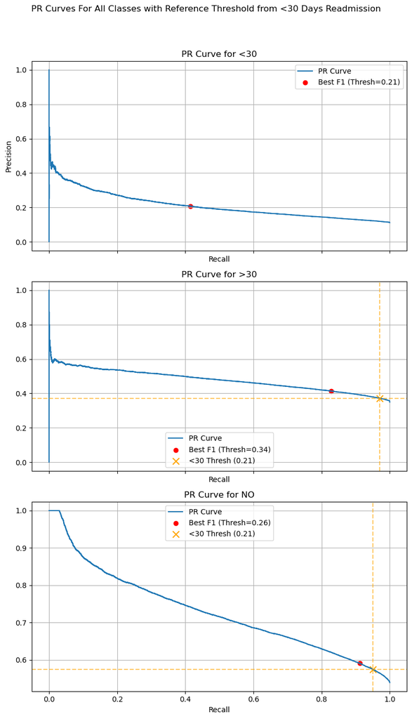

```python
# Precision-Recall Curves for All Classes at Selected Threshold
# fig, axes = plt.subplots(1, 3, figsize=(18, 5), sharey=True)
fig, axes = plt.subplots(3, 1, figsize=(8, 14), sharex=True)

# Save best threshold for <30 first
class_of_interest = le.transform(['<30'])[0]
binary_y_interest = (y_encoded == class_of_interest).astype(int)
_, _, thresholds_interest = precision_recall_curve(binary_y_interest, cv_proba[:, class_of_interest])
f1_interest = 2 * precision * recall / (precision + recall + 1e-8)
best_idx_interest = np.argmax(f1_interest)
best_thresh_interest = thresholds_interest[best_idx_interest]

# Plot PR curves
for idx, label in enumerate(class_labels):
    binary_y = (y_encoded == idx).astype(int)
    precision, recall, thresholds = precision_recall_curve(binary_y, cv_proba[:, idx])
    f1_scores = 2 * precision * recall / (precision + recall + 1e-8)
    best_idx = np.argmax(f1_scores)
    best_threshold = thresholds[best_idx] if best_idx < len(thresholds) else 0.5

    ax = axes[idx]
    ax.plot(recall, precision, label="PR Curve")
    ax.scatter(recall[best_idx], precision[best_idx], color='red',
               label=f'Best F1 (Thresh={best_threshold:.2f})')

    # If not the <30 class, show <30’s threshold as reference
    if idx != class_of_interest:
        # Find precision and recall at <30 threshold
        try:
            threshold_idx = np.argmin(np.abs(thresholds - best_thresh_interest))
            ax.scatter(recall[threshold_idx], precision[threshold_idx],
                       color='orange', marker='x', s=80,
                       label=f"<30 Thresh ({best_thresh_interest:.2f})")
            ax.axvline(recall[threshold_idx], color='orange', linestyle='--', alpha=0.6)
            ax.axhline(precision[threshold_idx], color='orange', linestyle='--', alpha=0.6)
        except Exception:
            pass  # fallback if threshold is out of range

    ax.set_title(f"PR Curve for {label}")
    ax.set_xlabel("Recall")
    if idx == 0:
        ax.set_ylabel("Precision")
    ax.legend()
    ax.grid(True)

plt.suptitle("PR Curves For All Classes with Reference Threshold from <30 Days Readmission")
plt.tight_layout(rect=[0, 0, 1, 0.95])
plt.show()
```

Precision-Recall curves for each readmission class show the trade-off between these two metrics. In other words, as recall, the correctly predicted proportion of each class, increase, precision, the proportion of correct predictions decreases. The threshold which optimizes F1 score for each class is shown in red and the threshold selected for optimizing for the `<30` class is marked by the yellow `X`.

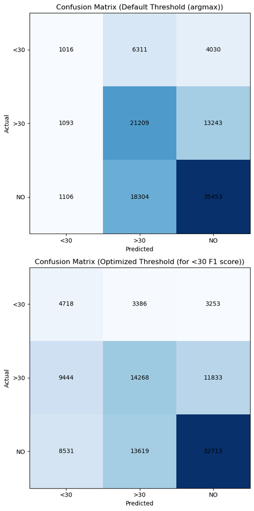

```python
# Confusion Matrices (Default vs Optimized)
# fig, (ax1, ax2) = plt.subplots(1, 2, figsize=(15, 6))
fig, (ax1, ax2) = plt.subplots(2, 1, figsize=(8, 12))

cm_default = confusion_matrix(y_true_str, y_pred_default_str, labels=readmit_order)
cm_optimized = confusion_matrix(y_true_str, y_pred_optimized_str, labels=readmit_order)

for ax, cm, title in zip([ax1, ax2], [cm_default, cm_optimized], ['Default Threshold (argmax)', 'Optimized Threshold (for <30 F1 score)']):
    im = ax.imshow(cm, cmap='Blues')
    ax.set_title(f'Confusion Matrix ({title})')
    ax.set_xticks(np.arange(len(readmit_order)))
    ax.set_yticks(np.arange(len(readmit_order)))
    ax.set_xticklabels(readmit_order)
    ax.set_yticklabels(readmit_order)
    ax.set_xlabel('Predicted')
    ax.set_ylabel('Actual')
    for i in range(len(readmit_order)):
        for j in range(len(readmit_order)):
            ax.text(j, i, cm[i, j], ha='center', va='center', color='black')
plt.tight_layout()
plt.show()
```

The confusion matrices help demonstrate the trade-offs in optimizing the classification threshold for the `<30` class. Using the default threshold, the argmax, only 1016 `<30` patients are correctly classified. Yet ~21,000 `>30` and ~35,000 `NO` classifications are correct. Lowering the threshold to 0.21 to optimize for correct predictions in the `<30` class, increases the number of correct predictions in that class to 4718 but also drastically increases the number in incorrect predictions from roughly 2000 to 18,000. This also reduces the correct `>30` and `NO` predictions to ~14,000 and ~32,000, respectively.

This will likely increase the cost of care for many patients, with the hope of improving the outcomes of many also.

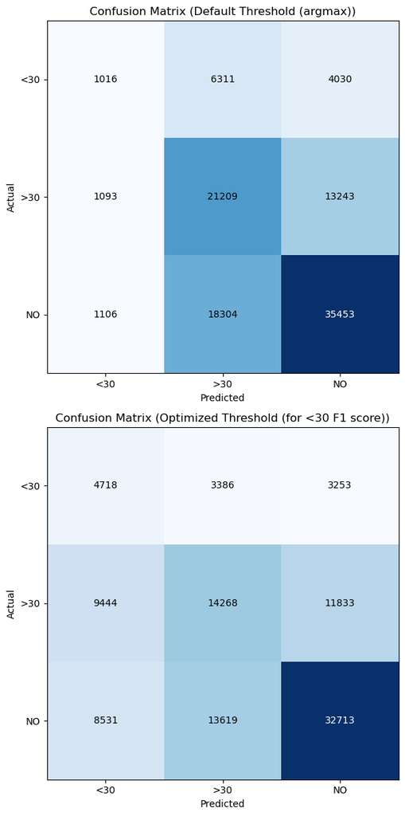

```python
# Confusion Matrices (Default vs Optimized)
fig, (ax1, ax2) = plt.subplots(2, 1, figsize=(8, 12))

cm_default = confusion_matrix(y_true_str, y_pred_default_str, labels=readmit_order)
cm_optimized = confusion_matrix(y_true_str, y_pred_optimized_str, labels=readmit_order)

for ax, cm, title in zip([ax1, ax2], [cm_default, cm_optimized], ['Default Threshold (argmax)', 'Optimized Threshold (for <30 F1 score)']):
    im = ax.imshow(cm, cmap='Blues')
    ax.set_title(f'Confusion Matrix ({title})')
    ax.set_xticks(np.arange(len(readmit_order)))
    ax.set_yticks(np.arange(len(readmit_order)))
    ax.set_xticklabels(readmit_order)
    ax.set_yticklabels(readmit_order)
    ax.set_xlabel('Predicted')
    ax.set_ylabel('Actual')

    # Get the color map and normalize the values
    norm = plt.Normalize(cm.min(), cm.max())
    colors = plt.cm.Blues(norm(cm))

    # Add text with adaptive color
    for i in range(len(readmit_order)):
        for j in range(len(readmit_order)):
            # Calculate the perceived brightness of the background
            # Using the formula: (0.299*R + 0.587*G + 0.114*B)
            bg_color = colors[i, j]
            brightness = 0.299 * bg_color[0] + 0.587 * bg_color[1] + 0.114 * bg_color[2]
            # Use white text for dark backgrounds, black for light backgrounds
            text_color = 'white' if brightness < 0.5 else 'black'
            ax.text(j, i, cm[i, j], ha='center', va='center', color=text_color)

plt.tight_layout()
plt.show()
```

```python
# Classification Report Comparison Table
report_default = classification_report(y_true_str, y_pred_default_str, target_names=readmit_order)
print(report_default)
report_optimized = classification_report(y_true_str, y_pred_optimized_str, target_names=readmit_order)
print(report_optimized)
```

```
              precision    recall  f1-score   support

         <30       0.32      0.09      0.14     11357
         >30       0.46      0.60      0.52     35545
          NO       0.67      0.65      0.66     54863

    accuracy                           0.57    101765
   macro avg       0.48      0.44      0.44    101765
weighted avg       0.56      0.57      0.55    101765

              precision    recall  f1-score   support

         <30       0.21      0.42      0.28     11357
         >30       0.46      0.40      0.43     35545
          NO       0.68      0.60      0.64     54863

    accuracy                           0.51    101765
   macro avg       0.45      0.47      0.45    101765
weighted avg       0.55      0.51      0.52    101765
```

```python
# # Classification Report Comparison Table
# report_default = classification_report(y_true_str, y_pred_default_str, target_names=readmit_order, output_dict=True)
# print(report_default)
# report_optimized = classification_report(y_true_str, y_pred_optimized_str, target_names=readmit_order, output_dict=True)
# print(report_optimized)

# report_comparison = []
# for class_name in readmit_order:
#     for metric in ['precision', 'recall', 'f1-score']:
#         report_comparison.append({
#             'Class': class_name,
#             'Metric': metric,
#             'Default': report_default[class_name][metric],
#             'Optimized': report_optimized[class_name][metric]
#         })
# report_comparison_df = pd.DataFrame(report_comparison)

# # These would be the default threshold metrics
# # Add all the metrics you want
# scoring = ['f1_weighted', 'accuracy']
# cv_scores = cross_validate(final_model, X, y_encoded, cv=cv, scoring=scoring) # doesn't allow for threshold setting

# # Compute means and stds
# metrics_summary = {
#     'f1_weighted': {
#         'mean': cv_scores['test_f1_weighted'].mean(),
#         'std': cv_scores['test_f1_weighted'].std()
#     },
#     'accuracy': {
#         'mean': cv_scores['test_accuracy'].mean(),
#         'std': cv_scores['test_accuracy'].std()
#     },
#     'weighted_accuracy': {
#         'mean': cv_scores['test_weighted_accuracy'].mean(),
#         'std': cv_scores['test_weighted_accuracy'].std()
#     }
# }

# # Append each to the report_comparison_df
# for metric_name, values in metrics_summary.items():
#     report_comparison_df.loc[len(report_comparison_df)] = {
#         'Class': 'Overall (CV)',
#         'Metric': metric_name,
#         'Default': values['mean'],
#         'Optimized': values['std']
#     }

# # Display or Export
# print("\n Classification Report Comparison:")
# print(report_comparison_df.round(4))
```

```python
# Setup
cv = StratifiedKFold(n_splits=5, shuffle=True, random_state=SEED)
class_of_interest = le.transform(['<30'])[0]

# Lists to collect metrics per fold
f1s, accs, precs, recs, aucs = [], [], [], [], []

# Lists to collect individual class AUC-ROC values
class_aucs = [[] for _ in range(len(le.classes_))]

# Cross-validation loop for custom threshold evaluation
for train_idx, test_idx in cv.split(X, y_encoded):
    X_train, X_test = X.iloc[train_idx], X.iloc[test_idx]
    y_train, y_test = y_encoded[train_idx], y_encoded[test_idx]

    # Train
    model = LogisticRegression(
        C=1.0,
        class_weight=int_class_weights,
        max_iter=2000,
        solver='lbfgs'
    )
    model.fit(X_train, y_train)

    # Predict probabilities
    proba = model.predict_proba(X_test)

    # Optimize threshold for <30 using training set
    binary_train = (y_train == class_of_interest).astype(int)
    train_proba = model.predict_proba(X_train)[:, class_of_interest]
    prec, rec, thresholds = precision_recall_curve(binary_train, train_proba)
    f1_scores = 2 * (prec * rec) / (prec + rec + 1e-8)
    best_idx = np.argmax(f1_scores)
    best_threshold = thresholds[best_idx] if best_idx < len(thresholds) else 0.5

    # Predict labels with optimized threshold
    y_pred_opt = np.array([
        class_of_interest if p[class_of_interest] >= best_threshold else np.argmax(p)
        for p in proba
    ])

    # Decode
    y_test_str = le.inverse_transform(y_test)
    y_pred_str = le.inverse_transform(y_pred_opt)

    # Metrics
    f1s.append(f1_score(y_test_str, y_pred_str, average='weighted'))
    accs.append(accuracy_score(y_test_str, y_pred_str))
    precs.append(precision_score(y_test_str, y_pred_str, average='weighted'))
    recs.append(recall_score(y_test_str, y_pred_str, average='weighted'))

    # Calculate individual class AUC-ROC values
    y_test_bin = label_binarize(y_test, classes=np.arange(len(le.classes_)))
    for i in range(len(le.classes_)):
        class_auc = roc_auc_score(y_test_bin[:, i], proba[:, i])
        class_aucs[i].append(class_auc)

    # Calculate weighted AUC-ROC
    aucs.append(roc_auc_score(y_test_bin, proba, multi_class='ovr', average='weighted'))


# Aggregate results
print("\n Custom Threshold Evaluation (5-fold CV):")
print(f"Accuracy      : {np.mean(accs):.4f} ± {np.std(accs):.4f}")
print(f"F1 (weighted) : {np.mean(f1s):.4f} ± {np.std(f1s):.4f}")
print(f"Precision (w) : {np.mean(precs):.4f} ± {np.std(precs):.4f}")
print(f"Recall (w)    : {np.mean(recs):.4f} ± {np.std(recs):.4f}")
print(f"AUC (w, ovr)    : {np.mean(aucs):.4f} ± {np.std(aucs):.4f}")

# Print individual class AUC-ROC values
print("\nIndividual Class AUC-ROC values:")
for i, class_name in enumerate(le.classes_):
    mean_auc = np.mean(class_aucs[i])
    std_auc = np.std(class_aucs[i])
    print(f"{class_name}: {mean_auc:.4f} ± {std_auc:.4f}")
```

```
 Custom Threshold Evaluation (5-fold CV):
Accuracy      : 0.5145 ± 0.0058
F1 (weighted) : 0.5284 ± 0.0040
Precision (w) : 0.5518 ± 0.0033
Recall (w)    : 0.5145 ± 0.0058
AUC (w, ovr)    : 0.6798 ± 0.0036

Individual Class AUC-ROC values:
<30: 0.6681 ± 0.0041
>30: 0.6562 ± 0.0030
NO: 0.6975 ± 0.0045
```

### Fit Final Model on All Training Data for Variable Importance

```python
final_model.fit(X, y_encoded)

final_model.coef_
```

```
array([[-2.33285193e-02, -3.23605369e-03,  5.52347660e-05, ...,
        -1.43339909e-02,  3.31257188e-01, -5.10618096e-01],
       [ 4.12038001e-02,  1.18776932e-02, -2.57413234e-02, ...,
        -4.14210398e-01, -4.12779324e-01,  5.01818491e-01],
       [-1.78752808e-02, -8.64163947e-03,  2.56860887e-02, ...,
         4.28544389e-01,  8.15221367e-02,  8.79960487e-03]],
      shape=(3, 1165))
```

```python
print("Original class labels:", le.classes_)
print("Model class labels   :", final_model.classes_)
```

```
Original class labels: ['<30' '>30' 'NO']
Model class labels   : [0 1 2]
```

```python
print("Coef shape:", final_model.coef_.shape)  # (n_classes, n_features)
print("Classes:", final_model.classes_)        # Check class order

# Get the class index for '<30'
class_index = np.where(final_model.classes_ == le.transform(['<30']))[0][0]

# Extract coefficients
coefs = final_model.coef_[class_index]  # 1D array of shape (n_features,)

feature_names = X.columns

coef_df = pd.DataFrame({
    'Feature': feature_names,
    'Coefficient': coefs,
    'Abs_Coefficient': np.abs(coefs)
})

# Sort by absolute magnitude
top_features = coef_df.sort_values(by='Abs_Coefficient', ascending=False)
print(top_features[['Feature', 'Coefficient']].head(15))
```

```
Coef shape: (3, 1165)
Classes: [0 1 2]
                          Feature  Coefficient
45    discharge_disposition_id_11    -2.127510
529                      diag_391     1.419779
881                       diag_82     1.418756
410                      diag_271     1.321121
625                      diag_506     1.297986
645                      diag_526     1.273526
969                      diag_923    -1.253320
1151                     diag_V60     1.212348
1012                     diag_977    -1.211145
950                      diag_904     1.206549
832                      diag_750     1.160188
690                      diag_579    -1.146135
46    discharge_disposition_id_12     1.137726
535                       diag_40    -1.120931
483                      diag_347     1.102896
```

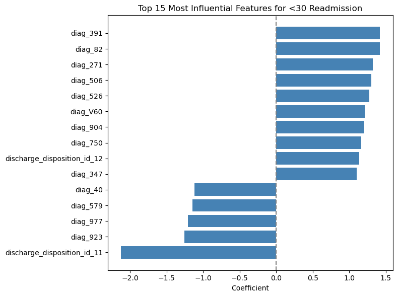

```python
top_n = 15
top_plot = top_features.head(top_n).sort_values(by='Coefficient')

plt.figure(figsize=(8, 6))
plt.barh(top_plot['Feature'], top_plot['Coefficient'], color='steelblue')
plt.axvline(0, color='gray', linestyle='--')
plt.xlabel("Coefficient")
plt.title("Top 15 Most Influential Features for <30 Readmission")
plt.tight_layout()
plt.show()
```

```python
# Get class labels (already encoded using LabelEncoder)
class_labels = le.inverse_transform(final_model.classes_)  # e.g. ['<30', '>30', 'NO']

# Get coefficient matrix: shape (n_classes, n_features)
coef_matrix = final_model.coef_

# Create DataFrame
coef_df = pd.DataFrame(coef_matrix.T, columns=class_labels, index=X.columns)

def get_top_abs_features(coef_df, class_name, k=10):
    """
    Returns top-k features by absolute value of coefficient for a given class.
    Merges top positive and negative contributors.
    """
    coefs = coef_df[class_name]
    # Take top k in both directions
    top_pos = coefs.sort_values(ascending=False).head(k)
    top_neg = coefs.sort_values(ascending=True).head(k)

    # Combine and compute absolute values
    combined = pd.concat([top_pos, top_neg]).drop_duplicates()
    result = combined.to_frame(name='Coefficient')
    result['Abs_Coefficient'] = result['Coefficient'].abs()

    # Sort by absolute value
    return result.sort_values(by='Abs_Coefficient', ascending=False).head(k)

for class_name in class_labels:
    top_abs = get_top_abs_features(coef_df, class_name, k=10)
    print(f" Top |Coefficient| features for class '{class_name}':")
    print(top_abs.round(4))
```

```
 Top |Coefficient| features for class '<30':
                             Coefficient  Abs_Coefficient
discharge_disposition_id_11      -2.1275           2.1275
diag_391                          1.4198           1.4198
diag_82                           1.4188           1.4188
diag_271                          1.3211           1.3211
diag_506                          1.2980           1.2980
diag_526                          1.2735           1.2735
diag_923                         -1.2533           1.2533
diag_V60                          1.2123           1.2123
diag_977                         -1.2111           1.2111
diag_904                          1.2065           1.2065
 Top |Coefficient| features for class '>30':
                             Coefficient  Abs_Coefficient
discharge_disposition_id_11      -2.1620           2.1620
discharge_disposition_id_14      -1.5065           1.5065
diag_366                          1.4559           1.4559
diag_271                         -1.2555           1.2555
diag_82                          -1.2489           1.2489
diag_964                         -1.1588           1.1588
diag_136                         -1.1117           1.1117
diag_40                           1.1076           1.1076
diag_66                           1.0748           1.0748
diag_448                          1.0699           1.0699
 Top |Coefficient| features for class 'NO':
                                 Coefficient  Abs_Coefficient
discharge_disposition_id_11           4.2895           4.2895
discharge_disposition_id_14           1.3940           1.3940
diag_826                             -1.3815           1.3815
admission_type_id_Trauma Center       1.3484           1.3484
diag_526                             -1.3012           1.3012
diag_E817                            -1.2505           1.2505
diag_664                              1.1967           1.1967
diag_720                              1.1861           1.1861
diag_643                             -1.1836           1.1836
diag_V27                              1.1381           1.1381
```

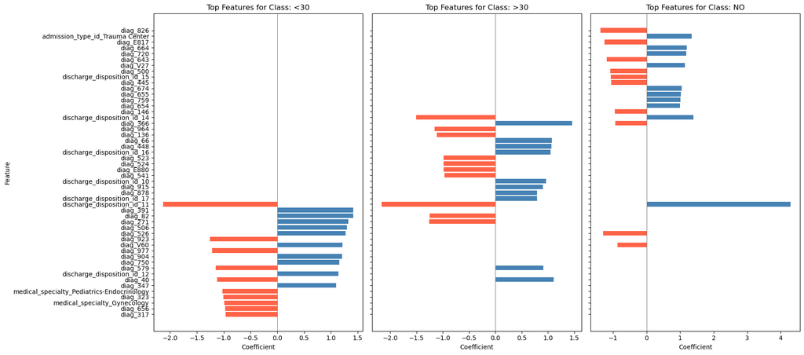

```python
def get_top_abs_features(coef_df, class_name, k=10):
    """
    Returns top-k features by absolute coefficient magnitude for one class.
    """
    coefs = coef_df[class_name]
    top_pos = coefs.sort_values(ascending=False).head(k)
    top_neg = coefs.sort_values(ascending=True).head(k)
    combined = pd.concat([top_pos, top_neg]).drop_duplicates()
    result = pd.DataFrame({
        'Feature': combined.index,
        'Coefficient': combined.values,
        'Abs_Coefficient': np.abs(combined.values),
        'Sign': np.where(combined.values >= 0, 'Positive', 'Negative')
    })
    result = result.sort_values(by='Abs_Coefficient', ascending=True)
    return result

# --- Create subplots ---
n_classes = len(class_labels)
fig, axes = plt.subplots(1, n_classes, figsize=(6 * n_classes, 8), sharey=True)

# Adjust if only one class (avoid axes being a single object)
if n_classes == 1:
    axes = [axes]

# --- Plot for each class ---
for i, class_name in enumerate(class_labels):
    top_df = get_top_abs_features(coef_df, class_name, k=10)

    ax = axes[i]
    colors = top_df['Sign'].map({'Positive': 'steelblue', 'Negative': 'tomato'})

    ax.barh(top_df['Feature'], top_df['Coefficient'], color=colors)
    ax.axvline(0, color='gray', linewidth=0.8)
    ax.set_title(f"Top Features for Class: {class_name}")
    ax.set_xlabel("Coefficient")
    if i == 0:
        ax.set_ylabel("Feature")

plt.tight_layout()
plt.show()
```

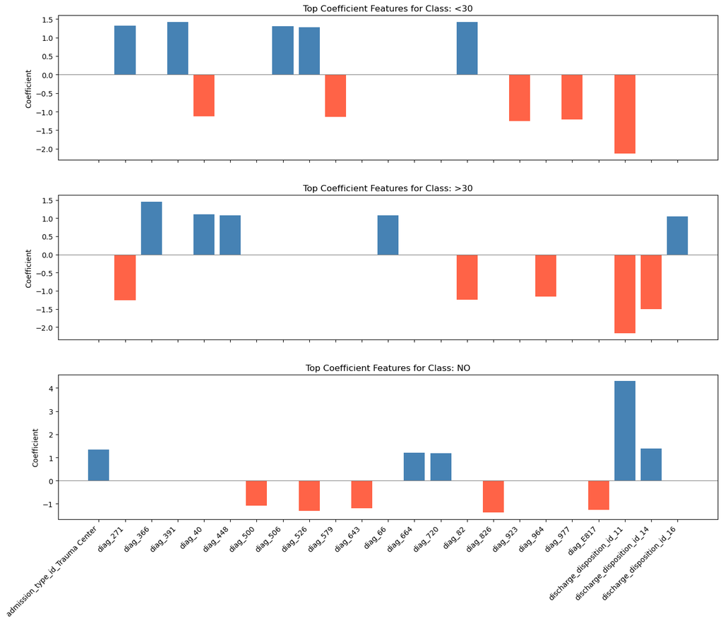

```python
def get_top_features_all_classes(coef_df, class_labels, k=5):
    feature_sets = []
    top_dict = {}

    for class_name in class_labels:
        coefs = coef_df[class_name]
        top_pos = coefs.sort_values(ascending=False).head(k)
        top_neg = coefs.sort_values(ascending=True).head(k)
        combined = pd.concat([top_pos, top_neg]).drop_duplicates()
        top_dict[class_name] = combined
        feature_sets.append(combined.index)

    # Unified list of unique top features
    all_features = pd.Index(np.unique(np.concatenate(feature_sets)))
    return all_features, top_dict

# Step 1: Get all top features and coefficients
shared_features, top_features_dict = get_top_features_all_classes(coef_df, class_labels, k=5)

# Step 2: Plot setup
n_classes = len(class_labels)
fig, axes = plt.subplots(nrows=n_classes, ncols=1, figsize=(14, 4 * n_classes), sharex=True)

if n_classes == 1:
    axes = [axes]

# Step 3: Plot each class
for i, class_name in enumerate(class_labels):
    ax = axes[i]
    coefs = top_features_dict[class_name].reindex(shared_features).fillna(0)
    colors = ['steelblue' if c >= 0 else 'tomato' for c in coefs]

    x_pos = np.arange(len(shared_features))
    ax.bar(x_pos, coefs, color=colors)
    ax.axhline(0, color='gray', linewidth=0.8)
    ax.set_title(f"Top Coefficient Features for Class: {class_name}")
    ax.set_ylabel("Coefficient")

# X-axis tick labels (only on bottom plot)
axes[-1].set_xticks(x_pos)
axes[-1].set_xticklabels(shared_features, rotation=45, ha='right')

plt.tight_layout(h_pad=3)
plt.show()
```

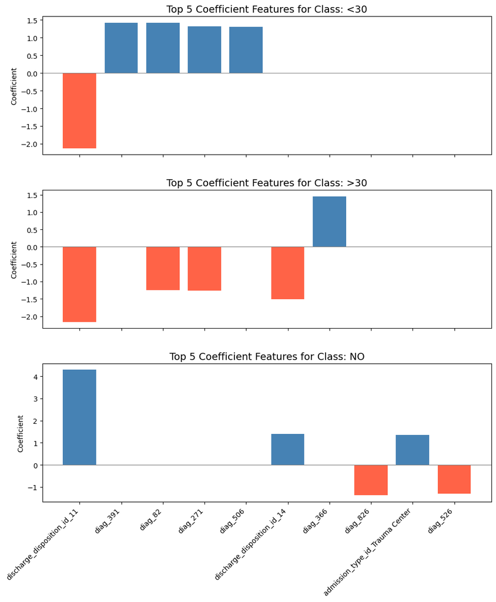

```python
def get_top5_per_class(coef_df, class_labels):
    """
    Collect top 5 features (by absolute coefficient) for each class independently.
    Return:
        - A unified list of all features used
        - A dictionary of class: top_5 coefficients (padded with 0s if needed)
    """
    top_dict = {}
    all_features = []

    for class_name in class_labels:
        coefs = coef_df[class_name]
        top_feats = coefs.reindex(coefs.abs().sort_values(ascending=False).head(5).index)
        top_dict[class_name] = top_feats
        all_features.extend(top_feats.index)

    # Keep order per class, but remove duplicates
    unique_features = list(dict.fromkeys(all_features))
    return unique_features, top_dict

# Step 1: Get the top 5 features for each class
shared_features, class_top_dict = get_top5_per_class(coef_df, class_labels)

# Step 2: Setup plot
n_classes = len(class_labels)
fig, axes = plt.subplots(nrows=n_classes, ncols=1, figsize=(10, 4 * n_classes), sharex=True)

if n_classes == 1:
    axes = [axes]

# Step 3: Plot each class
for i, class_name in enumerate(class_labels):
    ax = axes[i]
    coefs = class_top_dict[class_name].reindex(shared_features).fillna(0)
    colors = ['steelblue' if c >= 0 else 'tomato' for c in coefs]

    x_pos = np.arange(len(shared_features))
    ax.bar(x_pos, coefs, color=colors)
    ax.axhline(0, color='gray', linewidth=0.8)
    ax.set_title(f"Top 5 Coefficient Features for Class: {class_name}", fontsize=14)
    ax.set_ylabel("Coefficient")

# Shared X-axis (only on bottom)
axes[-1].set_xticks(x_pos)
axes[-1].set_xticklabels(shared_features, rotation=45, ha='right')

plt.tight_layout(h_pad=3)
plt.show()
```

### Visualize the Target Class Proportions

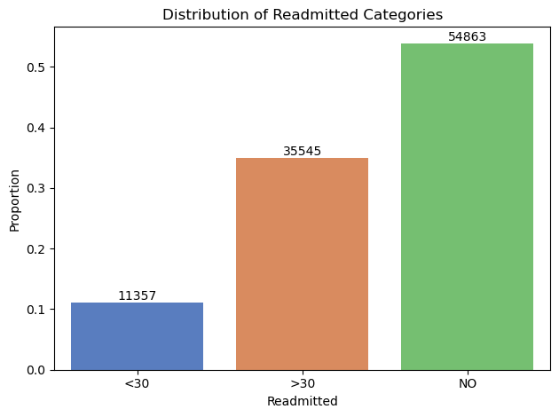

```python
# Set the color palette
palette = sns.color_palette("muted", n_colors=len(readmit_order))

# Calculate counts and proportions of each category
readmit_counts = imputed_data['readmitted'].value_counts(sort=False)  # Counts
readmit_proportions = readmit_counts / readmit_counts.sum()  # Proportions

# Plot the distribution
fig, ax = plt.subplots()
sns.barplot(
    x=readmit_proportions.index,
    y=readmit_proportions.values,
    hue=readmit_proportions.index,
    palette=palette,
    ax=ax
)

# Add titles and labels
ax.set_title('Distribution of Readmitted Categories')
ax.set_xlabel('Readmitted')
ax.set_ylabel('Proportion')

# Add counts as labels on top of each bar
for bar, count in zip(ax.patches, readmit_counts.values):
    ax.text(
        bar.get_x() + bar.get_width() / 2,  # x-coordinate
        bar.get_height(),                  # y-coordinate (bar height)
        f'{count}',                        # Text label
        ha='center', va='bottom',         # Center alignment
        fontsize=10
    )

plt.tight_layout()
# plt.savefig(f'plots/barplot_readmitted.png', bbox_inches="tight")
plt.show()
```